# 990-PF Efile Data Catalog

Private foundations · release efilepf_v3_1

[output not shown]

## About this release

### Data sources and processing

The Taxpayer First Act of 2019 made electronic filing mandatory for Form 990-PF for tax years beginning after July 1, 2019, so recent waves cover nearly every private foundation; earlier years include only foundations that chose to e-file. NCCS builds the database from the XML files indexed by the [Giving Tuesday 990 Data Commons](https://www.givingtuesday.org/data-commons/990-data-infrastructure/), supplemented with returns the IRS e-file index lists but the Data Commons index never picked up (see the release notes below).

Each XML element (xpath) is assigned to a research variable and a table by the **Master Concordance** ([concordance990](https://nonprofit-open-data-collective.github.io/concordance990/)), and the tables are built with the [ef2](https://nonprofit-open-data-collective.github.io/ef2/) package. A table holds one Part of the form: either one row per filing (**1:1**), or several rows per filing for repeating groups such as officers, grants paid, or capital gains (**1:M**). Tables in Part 99 hold the statements foundations attach to the return (accounting fees, depreciation, other investments, and so on).

The database also carries the two tables shared by every e-filed return: the filing header (`F9-P00-T00-HEADER`) and the signature block (`F9-P02-T00-SIGNATURE`). Here they hold 990-PF filings only. `F9_00_ORG_EXEMPT_TYPE` in the header is empty for 990-PF returns.

Efile data are organized by **tax year**, the year in which the foundation’s fiscal year begins (`TAX_PERIOD_BEGIN_DATE`). The IRS releases returns in monthly batches, so the most recent tax year is always incomplete. Form 990-PF was renumbered in 2023 (Part VI became Part V, and so on); the tables follow the pre-2023 numbering, and the part titles below give both.

Every table carries the keys needed to join tables to each other and to the BMF: `OBJECTID` (`OID-` followed by 18 digits, one per filing), `EIN2`, and `TAX_YEAR`. One-to-many tables add `TABLE_ID` (`TID-NNN-NNN-NNN`, one per row). Every row also carries `URL`, a link to the source XML return.

### R packages

- [ef2](https://nonprofit-open-data-collective.github.io/ef2/) Parses IRS 990 e-file XML into the relational tables published here.
- [concordance990](https://nonprofit-open-data-collective.github.io/concordance990/) The Master Concordance: maps XML xpaths to variables and tables; holds the data dictionaries.
- [panel990](https://nonprofit-open-data-collective.github.io/panel990/) Downloads efile tables and builds longitudinal panels, with BMF fields attached.
- [fiscal](https://nonprofit-open-data-collective.github.io/fiscal/) Fiscal health accounting metrics from 990 data.
- [governance](https://nonprofit-open-data-collective.github.io/governance/) Governance scores for nonprofits from Part VI.
- [peopleparser](https://nonprofit-open-data-collective.github.io/peopleparser/) Splits officer and director names into parts and infers gender.
- [titleclassifier](https://nonprofit-open-data-collective.github.io/titleclassifier/) Classifies officer titles into standard roles.

## Data dictionaries

Variable names, labels, descriptions, data types, and form locations for every table are documented in the concordance990 data dictionaries. Each table below links to its own section of the 990-PF dictionary.

Form 990-PF[Data dictionary (HTML)](https://nonprofit-open-data-collective.github.io/concordance990/articles/data-dictionary-990pf.html)[Data dictionary (PDF)](https://nonprofit-open-data-collective.github.io/concordance990/print/data-dictionary-990pf.pdf)

Form 990 / 990-EZ[Data dictionary (HTML)](https://nonprofit-open-data-collective.github.io/concordance990/articles/data-dictionary-990.html)[Data dictionary (PDF)](https://nonprofit-open-data-collective.github.io/concordance990/print/data-dictionary-990.pdf)

## Coverage

**E-filed returns by tax year and return type (efile_v3_1 and efilepf_v3_1)**

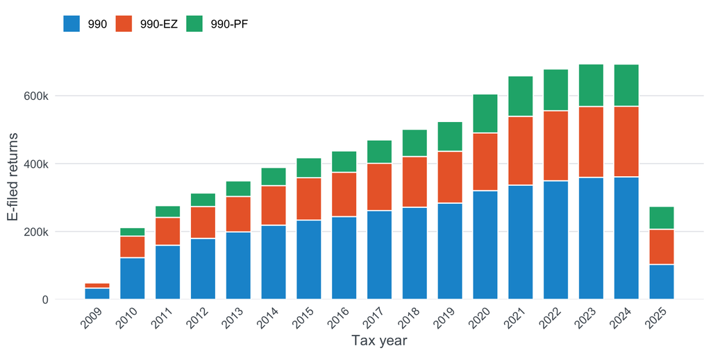

| Tax year | 990 | 990-EZ | 990-PF | Total |
| --- | --- | --- | --- | --- |
| 2009 | 33,311 | 15,470 | 2,345 | 51,126 |
| 2010 | 123,025 | 63,326 | 25,249 | 211,600 |
| 2011 | 159,504 | 82,048 | 34,597 | 276,149 |
| 2012 | 179,688 | 93,750 | 39,933 | 313,371 |
| 2013 | 198,855 | 104,375 | 45,887 | 349,117 |
| 2014 | 218,619 | 116,417 | 53,442 | 388,478 |
| 2015 | 233,519 | 124,894 | 58,815 | 417,228 |
| 2016 | 243,903 | 130,484 | 62,988 | 437,375 |
| 2017 | 261,612 | 139,145 | 68,950 | 469,707 |
| 2018 | 271,442 | 149,384 | 80,138 | 500,964 |
| 2019 | 283,694 | 152,623 | 87,789 | 524,106 |
| 2020 | 320,343 | 169,865 | 114,957 | 605,165 |
| 2021 | 336,489 | 202,729 | 119,354 | 658,572 |
| 2022 | 349,396 | 206,375 | 122,914 | 678,685 |
| 2023 | 359,351 | 208,863 | 125,565 | 693,779 |
| 2024 | 360,911 | 207,825 | 124,337 | 693,073 |
| 2025 | 102,869 | 103,732 | 67,525 | 274,126 |

## Table and file names

Table names follow the pattern **FF-PPP-TTT-NAME**, and each file appends the tax year: `PF-P15-T01-SUPPLEMENTARY-INFO-GRANT-PAID-2023.parquet`.

- **FF** is the form: `PF` = Form 990-PF; `F9` marks the two shared header tables.
- **PPP** is the part: `P01` = Part I, `P02` = Part II, and so on. `P00` is the heading and `P99` holds attached statements.
- **TTT** is the table: `T00` holds the one-to-one fields of the part, and `T01`, `T02`, … are its one-to-many tables.

Each table-year is published as **CSV** (readable anywhere) and **Parquet** (smaller and much faster in R with `arrow` or `duckdb`; panel990 reads Parquet by default). Both files hold the same rows and columns. Table-years with no filings are omitted from the listings below.

## Release notes

*Changes from `efilepf_v2_3` to `efilepf_v3_1`. Generated by `ef2::write_release_notes()` on 2026-10-09.*

#### Notes

- **New filings.** This release adds filings that the Giving Tuesday Data Commons (GTDC) index never listed. The IRS e-file index lists 184,165 such filings (990, 990-EZ and 990-PF; IRS batches 2025_09A, 2025_10A, the second half of 2026_05A, and 2026_08A). Their XML is re-hosted at `https://nccs-efile.s3.us-east-1.amazonaws.com/xml2/v2_3_patch/<OBJECT_ID>_public.xml`, with `PATCH-INDEX-v2_3-2026-10-07.csv` beside them. The build index combined the GTDC index of 2026-08-25 with that patch, one row per filing.
- **TY2025** is new: built from the combined index. Many TY2025 returns are not filed yet, so expect it to grow.
- **Labels** follow concordance990 2.0.1 (commit `02de916`). Relabelling moved some xpaths between tables; where the builders already selected those cells by xpath, the published tables are unchanged.
- **Keys.** `OBJECTID` is `OID-` + 18 digits, and `TABLE_ID` is the fixed-width `TID-NNN-NNN-NNN` (EF2-17), in every table.
- **Record.** `dev/UPSTREAM-ISSUES.md` (EF2-18) in the ef2 repository documents how this release was built and checked.
- **Also added:** 5,298 GTDC-indexed 990-PF filings for TY2016-2019 that the September 2026 PF build missed.
- **Header table.** The shared `F9-P00-T00-HEADER` gains `F9_00_ORG_EXEMPT_TYPE`, which is empty for 990-PF filings (it is derived from 990 and 990-EZ paths only).
- **multi_value** variables are still joined with `;` in filing order (EF2-13 fix 2); the concordance changed which variables are multi-valued (see below).

#### Filings by tax year

| Tax year | efilepf_v2_3 | efilepf_v3_1 | Change |
| --- | --- | --- | --- |
| 2009 | 2,345 | 2,345 | 0 |
| 2010 | 25,249 | 25,249 | 0 |
| 2011 | 34,597 | 34,597 | 0 |
| 2012 | 39,933 | 39,933 | 0 |
| 2013 | 45,887 | 45,887 | 0 |
| 2014 | 53,442 | 53,442 | 0 |
| 2015 | 58,815 | 58,815 | 0 |
| 2016 | 62,979 | 62,988 | +9 |
| 2017 | 68,260 | 68,950 | +690 |
| 2018 | 75,540 | 80,138 | +4,598 |
| 2019 | 87,788 | 87,789 | +1 |
| 2020 | 114,957 | 114,957 | 0 |
| 2021 | 119,354 | 119,354 | 0 |
| 2022 | 122,819 | 122,914 | +95 |
| 2023 | 124,529 | 125,565 | +1,036 |
| 2024 | 114,820 | 124,337 | +9,517 |
| 2025 | 0 | 67,525 | +67,525 |

By return type:

| Tax year | Return type | efilepf_v2_3 | efilepf_v3_1 | Change |
| --- | --- | --- | --- | --- |
| 2016 | 990PF | 62,979 | 62,988 | +9 |
| 2017 | 990PF | 68,260 | 68,950 | +690 |
| 2018 | 990PF | 75,540 | 80,138 | +4,598 |
| 2019 | 990PF | 87,788 | 87,789 | +1 |
| 2022 | 990PF | 122,819 | 122,914 | +95 |
| 2023 | 990PF | 124,529 | 125,565 | +1,036 |
| 2024 | 990PF | 114,820 | 124,337 | +9,517 |
| 2025 | 990PF | 0 | 67,525 | +67,525 |

#### Tables added and dropped

Added:

| Table | Years |
| --- | --- |
| PF-P09-T00-CHARITABLE-ACTIVITIES | 2009-2025 |

Dropped:

| Table | Years |
| --- | --- |
| PF-P09-T01-CHARITABLE-ACTIVITIES | 2009-2024 |
| PF-P09-T02-PROG-RELATED-INVESTMENTS | 2009-2024 |

#### Column changes

Columns added or removed in tables present in both releases, with the tax years affected.

| Table | Change | Column | Years |
| --- | --- | --- | --- |
| F9-P00-T00-HEADER | added | `F9_00_IRS_SEC_ACTIVE_PREP_TIME` | 2020 |
| F9-P00-T00-HEADER | added | `F9_00_IRS_SEC_AUTH_REVIEW_TXT` | 2020 |
| F9-P00-T00-HEADER | added | `F9_00_IRS_SEC_PREP_SUBMIT_TIME` | 2020 |
| F9-P00-T00-HEADER | added | `F9_00_IRS_SEC_VENDOR_CTRL_NUM` | 2020 |
| F9-P00-T00-HEADER | added | `F9_00_IRS_TRUST_PAY_DECLINED_CD` | 2020 |
| F9-P00-T00-HEADER | added | `F9_00_ORG_EXEMPT_TYPE` | 2009-2024 |
| PF-P09-T00-PROG-RELATED-INVESTMENTS | added | `PF_09_PROG_RLTD_INVEST_AMT_1` | 2009-2024 |
| PF-P09-T00-PROG-RELATED-INVESTMENTS | added | `PF_09_PROG_RLTD_INVEST_AMT_2` | 2009-2024 |
| PF-P09-T00-PROG-RELATED-INVESTMENTS | added | `PF_09_PROG_RLTD_INVEST_AMT_3` | 2009-2024 |
| PF-P09-T00-PROG-RELATED-INVESTMENTS | added | `PF_09_PROG_RLTD_INVEST_DESC_1` | 2009-2024 |
| PF-P09-T00-PROG-RELATED-INVESTMENTS | added | `PF_09_PROG_RLTD_INVEST_DESC_2` | 2009-2024 |

#### Row-count changes

Tables whose row counts changed, summed over the years that changed.

| Table | Years | efilepf_v2_3 | efilepf_v3_1 | Change |
| --- | --- | --- | --- | --- |
| PF-P04-T01-INVEST-INCOME-TAX-CAPITAL-GAINLOSS | 2016-2019, 2022-2024 | 15,833,012 | 16,170,687 | +337,675 |
| PF-P09-T00-PROG-RELATED-INVESTMENTS | 2009-2024 | 455,640 | 678,164 | +222,524 |
| PF-P15-T01-SUPPLEMENTARY-INFO-GRANT-PAID | 2016-2019, 2022-2024 | 9,308,389 | 9,484,858 | +176,469 |
| PF-P99-T24-INVEST-CORP-STOCK | 2016-2018, 2022-2024 | 4,943,725 | 5,090,967 | +147,242 |
| PF-P08-T01-COMPENSATION | 2016-2019, 2022-2024 | 2,115,747 | 2,168,344 | +52,597 |
| PF-P99-T36-EXP-OTH | 2016-2019, 2022-2024 | 1,623,799 | 1,665,882 | +42,083 |
| PF-P99-T27-INVEST-OTH | 2016-2019, 2022-2024 | 2,158,440 | 2,193,989 | +35,549 |
| PF-P99-T23-INVEST-CORP-BOND | 2016-2018, 2022-2024 | 776,858 | 797,899 | +21,041 |
| PF-P99-T49-TAXES | 2016-2019, 2022-2024 | 870,283 | 891,018 | +20,735 |
| PF-P99-T11-DEPREC | 2017-2018, 2022-2024 | 500,014 | 518,498 | +18,484 |
| F9-P00-T00-HEADER | 2016-2019, 2022-2024 | 656,735 | 672,681 | +15,946 |
| F9-P02-T00-SIGNATURE | 2016-2019, 2022-2024 | 656,735 | 672,681 | +15,946 |
| PF-P00-T00-HEADER | 2016-2019, 2022-2024 | 656,735 | 672,681 | +15,946 |
| PF-P01-T00-REVENUE-EXPENSE | 2016-2019, 2022-2024 | 656,735 | 672,681 | +15,946 |
| PF-P02-T00-BALANCE-SHEET | 2016-2019, 2022-2024 | 656,735 | 672,681 | +15,946 |
| PF-P07-T00-ACTIVITIES | 2016-2019, 2022-2024 | 656,733 | 672,679 | +15,946 |
| PF-P12-T00-QUALIFYING-DISTRIBUTIONS | 2016-2019, 2022-2024 | 656,717 | 672,663 | +15,946 |
| PF-P11-T00-DISTRIBUTABLE-AMOUNT | 2016-2019, 2022-2024 | 656,611 | 672,553 | +15,942 |
| PF-P17-T00-RELATIONSHIPS | 2016-2019, 2022-2024 | 652,065 | 667,882 | +15,817 |
| PF-P17-T00-TRANSFERS-TRANSACTIONS | 2016-2019, 2022-2024 | 652,065 | 667,882 | +15,817 |
| PF-P06-T00-INVEST-INCOME-EXCISE-TAX | 2016-2019, 2022-2024 | 652,913 | 668,724 | +15,811 |
| PF-P07-T00-ACTIVITIES-4720 | 2016-2019, 2022-2024 | 648,331 | 664,085 | +15,754 |
| PF-P10-T00-MINIMUM-INVESTMENT-RETURN | 2016-2019, 2022-2024 | 645,951 | 661,527 | +15,576 |
| PF-P03-T00-NET-ASSET-FUND-BALANCE-CHANGE | 2016-2019, 2022-2024 | 643,067 | 658,566 | +15,499 |
| PF-P13-T00-UNDISTRIBUTED-INCOME | 2016-2019, 2022-2024 | 621,308 | 636,314 | +15,006 |
| PF-P08-T00-COMPENSATION-CONTRACTORS | 2016-2019, 2022-2024 | 590,583 | 604,976 | +14,393 |
| PF-P08-T00-COMPENSATION-HIGHEST | 2016-2019, 2022-2024 | 589,896 | 604,233 | +14,337 |
| PF-P16-T00-INCOME-PRODUCING-ACTS | 2016-2019, 2022-2024 | 579,624 | 593,301 | +13,677 |
| PF-P15-T00-SUPPLEMENTARY-INFO-GRANT-PAID | 2016-2019, 2022-2024 | 571,686 | 585,159 | +13,473 |
| PF-P15-T00-SUPPLEMENTARY-INFO | 2016-2019, 2022-2024 | 524,044 | 536,623 | +12,579 |
| SB-P01-T01-CONTRIBUTORS | 2017-2018, 2022-2024 | 290,068 | 300,441 | +10,373 |
| PF-P99-T01-ACC-FEES | 2016-2019, 2022-2024 | 411,681 | 421,572 | +9,891 |
| PF-P99-T28-LAND-ETC | 2017-2018, 2022-2024 | 274,267 | 283,826 | +9,559 |
| PF-P04-T00-INVEST-INCOME-TAX-CAPITAL-GAINLOSS | 2016-2019, 2022-2024 | 396,282 | 405,176 | +8,894 |
| PF-P99-T42-PROF-FEES-OTH | 2016-2019, 2022-2024 | 312,547 | 320,112 | +7,565 |
| PF-P99-T37-INCOME-OTH | 2016-2018, 2022-2024 | 300,593 | 307,807 | +7,214 |
| PF-P15-T00-SUPPLEMENTARY-INFO-GRANT-FUTURE | 2016-2019, 2022-2024 | 274,739 | 281,412 | +6,673 |
| PF-P99-T35-DECREASE-OTH | 2016-2018, 2022-2024 | 248,940 | 255,387 | +6,447 |
| PF-P99-T33-ASSET-OTH | 2016-2018, 2022-2024 | 184,387 | 190,471 | +6,084 |
| PF-P99-T20-SALE-OTH-ASSET | 2017-2018, 2022-2024 | 213,455 | 219,340 | +5,885 |
| PF-P99-T38-INCREASE-OTH | 2016-2018, 2022-2024 | 194,566 | 200,258 | +5,692 |
| PF-P16-T02-INCOME-PRODUCING-ACTS | 2017-2018, 2022-2024 | 200,837 | 205,921 | +5,084 |
| PF-P05-T00-NET-INVEST-INCOME-TAX-4940E | 2016-2019 | 264,106 | 268,808 | +4,702 |
| SB-P00-T00-HEADER | 2017-2018, 2022-2024 | 131,615 | 135,846 | +4,231 |
| PF-P16-T03-ACTS-RELATIONSHIP-EXEMPT-PURPOSE | 2016-2018, 2022-2024 | 138,859 | 142,819 | +3,960 |
| SB-P02-T01-NONCASH-PROPERTY | 2017-2018, 2022-2024 | 111,513 | 115,363 | +3,850 |
| PF-P15-T03-SUPPLEMENTARY-INFO-GRANT-APP | 2016-2018, 2022-2024 | 144,188 | 148,033 | +3,845 |
| PF-P16-T01-INCOME-PRODUCING-ACTS | 2017-2018, 2022-2024 | 136,404 | 140,126 | +3,722 |
| PF-P15-T02-SUPPLEMENTARY-INFO-GRANT-FUTURE | 2017-2018, 2022-2024 | 195,180 | 198,511 | +3,331 |
| PF-P99-T29-LEGAL-FEES | 2017-2018, 2022-2024 | 84,874 | 87,524 | +2,650 |
| PF-P99-T39-LIAB-OTH | 2017-2018, 2022-2024 | 70,142 | 72,418 | +2,276 |
| PF-P14-T00-PRIVATE-OPERATING-FOUNDATIONS | 2017-2018, 2022-2024 | 53,397 | 55,274 | +1,877 |
| PF-P99-T26-INVEST-LAND | 2017-2018, 2022-2024 | 47,297 | 49,147 | +1,850 |
| PF-P99-T22-SUPPLEMENTAL-INFO | 2016-2018, 2022-2024 | 38,146 | 39,700 | +1,554 |
| PF-P99-T48-CONTRIBUTOR | 2016-2018, 2022-2024 | 61,551 | 63,094 | +1,543 |
| PF-P99-T00-AUXILLIARY | 2016-2018, 2022-2024 | 51,339 | 52,804 | +1,465 |
| PF-P08-T03-COMPENSATION-CONTRACTORS | 2017-2018, 2022-2024 | 40,605 | 41,920 | +1,315 |
| PF-P99-T25-INVEST-GOVT-SEC | 2016-2018, 2022-2024 | 42,200 | 43,357 | +1,157 |
| PF-P99-T16-EXP-RESPONSIBILITY | 2017-2018, 2022-2024 | 59,939 | 61,034 | +1,095 |
| PF-P08-T02-COMPENSATION-HIGHEST | 2017-2018, 2022-2024 | 31,631 | 32,651 | +1,020 |

*… and 19 more.*

#### Concordance changes

Xpaths moved between tables:

| From | To | Xpaths |
| --- | --- | --- |
| PF-P09-T01-CHARITABLE-ACTIVITIES | PF-P09-T00-CHARITABLE-ACTIVITIES | 16 |
| PF-P09-T02-PROG-RELATED-INVESTMENTS | PF-P09-T00-PROG-RELATED-INVESTMENTS | 10 |

Newly mapped xpaths, by table:

| Table | Xpaths |
| --- | --- |
| F9-P00-T00-HEADER | 7 |

Renamed variables:

*None.*

`multi_value` changes:

| Variable | From | To |
| --- | --- | --- |
| PF_AX02_ACT_NEW_EXPLANATION | (blank) | TRUE |
| PF_AX44_CAUSE_EXPLANATION | (blank) | TRUE |
| PF_AX45_REDUCT_EXPLANATION | (blank) | TRUE |

[Release notes on S3](https://nccs-efile.s3.us-east-1.amazonaws.com/public/efilepf_v3_1/RELEASE-NOTES-EFILEPF_V3_1.md)

## Version history

Every release stays on S3 and keeps its catalog page, so earlier analyses can be reproduced. **Interim** releases were built and posted but not announced as full public releases.

| Release | Returns | Published | Status | Tax years | Tables | Filings | Notes |
| --- | --- | --- | --- | --- | --- | --- | --- |
| `efile_v3_1` | 990, 990-EZ | 2026-10-09 | Current | 2009–2025 | 136 | 6,307,836 | [Release notes](https://nccs-efile.s3.us-east-1.amazonaws.com/public/efile_v3_1/RELEASE-NOTES-EFILE_V3_1.md) |
| `efilepf_v3_1` this page | 990-PF | 2026-10-09 | Current | 2009–2025 | 83 | 1,234,785 | [Release notes](https://nccs-efile.s3.us-east-1.amazonaws.com/public/efilepf_v3_1/RELEASE-NOTES-EFILEPF_V3_1.md) |
| `efile_v2_3` | 990, 990-EZ | 2026-10-07 | Interim | 2009–2024 | 136 | 5,981,036 | — |
| `efilepf_v2_3` | 990-PF | 2026-10-07 | Interim | 2009–2024 | 84 | 1,151,314 | — |
| `efile_v2_2` | 990, 990-EZ | 2026-08-11 | Interim | 2009–2024 | 112 | 5,675,704 | — |
| `efile_v2_1` | 990, 990-EZ | 2025-10-28 | Archived | 2009–2024 | 112 | 5,675,704 | — |
| `efile_v2_0` | 990, 990-EZ | 2025-03-22 | Archived | 2009–2023 | 111 | 5,159,432 | — |
| `efile_v1` | 990, 990-EZ | 2023-03-21 | Archived | — | — | — | — |

# Available tables

Each table lists its files by tax year. The code below each table uses `panelize()` from [panel990](https://nonprofit-open-data-collective.github.io/panel990/) to download a multi-year panel of the table with BMF organization fields (NTEE codes, geography, subsection) attached.

**Anchor your code to a release.** `panelize()` reads the current release (`efile_version()`) unless told otherwise, so the same code returns different data after the next release. For reproducible results, name the release explicitly:

```r
panel <-
  panelize( tables = "PF-P01-T00-REVENUE-EXPENSE",
            years = 2020:2024,
            source = data_source( version = "v3_1", form = "990PF" ),
            bmf = TRUE )
```

BMF fields come from the current NCCS master BMF. To fix those as well, save the BMF once and pass the data frame or file path to `bmf =`.

## Shared tables (every e-filed return)

### P00 Heading (items A-O)

#### F9-P00-T00-HEADER

1:1 one row per filing · tax years 2009–2025 · 1,234,785 rows · [Data dictionary](https://nonprofit-open-data-collective.github.io/concordance990/articles/data-dictionary-990pf.html#f9-p00-t00-header)

| Year | Table | CSV | Parquet | Rows |
| --- | --- | --- | --- | --- |
| 2025 | `F9-P00-T00-HEADER-2025` | CSV | [Parquet](https://nccs-efile.s3.us-east-1.amazonaws.com/public/efilepf_v3_1/F9-P00-T00-HEADER-2025.parquet) | 67,525 |
| 2024 | `F9-P00-T00-HEADER-2024` | CSV | [Parquet](https://nccs-efile.s3.us-east-1.amazonaws.com/public/efilepf_v3_1/F9-P00-T00-HEADER-2024.parquet) | 124,337 |
| 2023 | `F9-P00-T00-HEADER-2023` | CSV | [Parquet](https://nccs-efile.s3.us-east-1.amazonaws.com/public/efilepf_v3_1/F9-P00-T00-HEADER-2023.parquet) | 125,565 |
| 2022 | `F9-P00-T00-HEADER-2022` | CSV | [Parquet](https://nccs-efile.s3.us-east-1.amazonaws.com/public/efilepf_v3_1/F9-P00-T00-HEADER-2022.parquet) | 122,914 |
| 2021 | `F9-P00-T00-HEADER-2021` | CSV | [Parquet](https://nccs-efile.s3.us-east-1.amazonaws.com/public/efilepf_v3_1/F9-P00-T00-HEADER-2021.parquet) | 119,354 |
| 2020 | `F9-P00-T00-HEADER-2020` | CSV | [Parquet](https://nccs-efile.s3.us-east-1.amazonaws.com/public/efilepf_v3_1/F9-P00-T00-HEADER-2020.parquet) | 114,957 |
| 2019 | `F9-P00-T00-HEADER-2019` | CSV | [Parquet](https://nccs-efile.s3.us-east-1.amazonaws.com/public/efilepf_v3_1/F9-P00-T00-HEADER-2019.parquet) | 87,789 |
| 2018 | `F9-P00-T00-HEADER-2018` | CSV | [Parquet](https://nccs-efile.s3.us-east-1.amazonaws.com/public/efilepf_v3_1/F9-P00-T00-HEADER-2018.parquet) | 80,138 |
| 2017 | `F9-P00-T00-HEADER-2017` | CSV | [Parquet](https://nccs-efile.s3.us-east-1.amazonaws.com/public/efilepf_v3_1/F9-P00-T00-HEADER-2017.parquet) | 68,950 |
| 2016 | `F9-P00-T00-HEADER-2016` | CSV | [Parquet](https://nccs-efile.s3.us-east-1.amazonaws.com/public/efilepf_v3_1/F9-P00-T00-HEADER-2016.parquet) | 62,988 |
| 2015 | `F9-P00-T00-HEADER-2015` | CSV | [Parquet](https://nccs-efile.s3.us-east-1.amazonaws.com/public/efilepf_v3_1/F9-P00-T00-HEADER-2015.parquet) | 58,815 |
| 2014 | `F9-P00-T00-HEADER-2014` | CSV | [Parquet](https://nccs-efile.s3.us-east-1.amazonaws.com/public/efilepf_v3_1/F9-P00-T00-HEADER-2014.parquet) | 53,442 |
| 2013 | `F9-P00-T00-HEADER-2013` | CSV | [Parquet](https://nccs-efile.s3.us-east-1.amazonaws.com/public/efilepf_v3_1/F9-P00-T00-HEADER-2013.parquet) | 45,887 |
| 2012 | `F9-P00-T00-HEADER-2012` | CSV | [Parquet](https://nccs-efile.s3.us-east-1.amazonaws.com/public/efilepf_v3_1/F9-P00-T00-HEADER-2012.parquet) | 39,933 |
| 2011 | `F9-P00-T00-HEADER-2011` | CSV | [Parquet](https://nccs-efile.s3.us-east-1.amazonaws.com/public/efilepf_v3_1/F9-P00-T00-HEADER-2011.parquet) | 34,597 |
| 2010 | `F9-P00-T00-HEADER-2010` | CSV | [Parquet](https://nccs-efile.s3.us-east-1.amazonaws.com/public/efilepf_v3_1/F9-P00-T00-HEADER-2010.parquet) | 25,249 |
| 2009 | `F9-P00-T00-HEADER-2009` | CSV | [Parquet](https://nccs-efile.s3.us-east-1.amazonaws.com/public/efilepf_v3_1/F9-P00-T00-HEADER-2009.parquet) | 2,345 |

**Download with panel990**

```
library( panel990 )

# Panel of tax years 2020-2024
# with BMF fields appended

panel <-
  panelize( tables = "F9-P00-T00-HEADER",
            years = 2020:2024,
            source = data_source( form = "990PF" ),
            bmf = TRUE )

df <- panel_data( panel )
```

Back to contents

### P02 Part II - Signature Block

#### F9-P02-T00-SIGNATURE

1:1 one row per filing · tax years 2009–2025 · 1,234,785 rows · [Data dictionary](https://nonprofit-open-data-collective.github.io/concordance990/articles/data-dictionary-990pf.html#f9-p02-t00-signature)

| Year | Table | CSV | Parquet | Rows |
| --- | --- | --- | --- | --- |
| 2025 | `F9-P02-T00-SIGNATURE-2025` | CSV | [Parquet](https://nccs-efile.s3.us-east-1.amazonaws.com/public/efilepf_v3_1/F9-P02-T00-SIGNATURE-2025.parquet) | 67,525 |
| 2024 | `F9-P02-T00-SIGNATURE-2024` | CSV | [Parquet](https://nccs-efile.s3.us-east-1.amazonaws.com/public/efilepf_v3_1/F9-P02-T00-SIGNATURE-2024.parquet) | 124,337 |
| 2023 | `F9-P02-T00-SIGNATURE-2023` | CSV | [Parquet](https://nccs-efile.s3.us-east-1.amazonaws.com/public/efilepf_v3_1/F9-P02-T00-SIGNATURE-2023.parquet) | 125,565 |
| 2022 | `F9-P02-T00-SIGNATURE-2022` | CSV | [Parquet](https://nccs-efile.s3.us-east-1.amazonaws.com/public/efilepf_v3_1/F9-P02-T00-SIGNATURE-2022.parquet) | 122,914 |
| 2021 | `F9-P02-T00-SIGNATURE-2021` | CSV | [Parquet](https://nccs-efile.s3.us-east-1.amazonaws.com/public/efilepf_v3_1/F9-P02-T00-SIGNATURE-2021.parquet) | 119,354 |
| 2020 | `F9-P02-T00-SIGNATURE-2020` | CSV | [Parquet](https://nccs-efile.s3.us-east-1.amazonaws.com/public/efilepf_v3_1/F9-P02-T00-SIGNATURE-2020.parquet) | 114,957 |
| 2019 | `F9-P02-T00-SIGNATURE-2019` | CSV | [Parquet](https://nccs-efile.s3.us-east-1.amazonaws.com/public/efilepf_v3_1/F9-P02-T00-SIGNATURE-2019.parquet) | 87,789 |
| 2018 | `F9-P02-T00-SIGNATURE-2018` | CSV | [Parquet](https://nccs-efile.s3.us-east-1.amazonaws.com/public/efilepf_v3_1/F9-P02-T00-SIGNATURE-2018.parquet) | 80,138 |
| 2017 | `F9-P02-T00-SIGNATURE-2017` | CSV | [Parquet](https://nccs-efile.s3.us-east-1.amazonaws.com/public/efilepf_v3_1/F9-P02-T00-SIGNATURE-2017.parquet) | 68,950 |
| 2016 | `F9-P02-T00-SIGNATURE-2016` | CSV | [Parquet](https://nccs-efile.s3.us-east-1.amazonaws.com/public/efilepf_v3_1/F9-P02-T00-SIGNATURE-2016.parquet) | 62,988 |
| 2015 | `F9-P02-T00-SIGNATURE-2015` | CSV | [Parquet](https://nccs-efile.s3.us-east-1.amazonaws.com/public/efilepf_v3_1/F9-P02-T00-SIGNATURE-2015.parquet) | 58,815 |
| 2014 | `F9-P02-T00-SIGNATURE-2014` | CSV | [Parquet](https://nccs-efile.s3.us-east-1.amazonaws.com/public/efilepf_v3_1/F9-P02-T00-SIGNATURE-2014.parquet) | 53,442 |
| 2013 | `F9-P02-T00-SIGNATURE-2013` | CSV | [Parquet](https://nccs-efile.s3.us-east-1.amazonaws.com/public/efilepf_v3_1/F9-P02-T00-SIGNATURE-2013.parquet) | 45,887 |
| 2012 | `F9-P02-T00-SIGNATURE-2012` | CSV | [Parquet](https://nccs-efile.s3.us-east-1.amazonaws.com/public/efilepf_v3_1/F9-P02-T00-SIGNATURE-2012.parquet) | 39,933 |
| 2011 | `F9-P02-T00-SIGNATURE-2011` | CSV | [Parquet](https://nccs-efile.s3.us-east-1.amazonaws.com/public/efilepf_v3_1/F9-P02-T00-SIGNATURE-2011.parquet) | 34,597 |
| 2010 | `F9-P02-T00-SIGNATURE-2010` | CSV | [Parquet](https://nccs-efile.s3.us-east-1.amazonaws.com/public/efilepf_v3_1/F9-P02-T00-SIGNATURE-2010.parquet) | 25,249 |
| 2009 | `F9-P02-T00-SIGNATURE-2009` | CSV | [Parquet](https://nccs-efile.s3.us-east-1.amazonaws.com/public/efilepf_v3_1/F9-P02-T00-SIGNATURE-2009.parquet) | 2,345 |

**Download with panel990**

```
library( panel990 )

# Panel of tax years 2020-2024
# with BMF fields appended

panel <-
  panelize( tables = "F9-P02-T00-SIGNATURE",
            years = 2020:2024,
            source = data_source( form = "990PF" ),
            bmf = TRUE )

df <- panel_data( panel )
```

Back to contents

## Schedule B: Schedule of Contributors

### P00 Heading - Organization Type and Filing Rules

#### SB-P00-T00-HEADER

1:1 one row per filing · tax years 2009–2025 · 324,714 rows · [Data dictionary](https://nonprofit-open-data-collective.github.io/concordance990/articles/data-dictionary-990pf.html#sb-p00-t00-header)

| Year | Table | CSV | Parquet | Rows |
| --- | --- | --- | --- | --- |
| 2025 | `SB-P00-T00-HEADER-2025` | CSV | [Parquet](https://nccs-efile.s3.us-east-1.amazonaws.com/public/efilepf_v3_1/SB-P00-T00-HEADER-2025.parquet) | 15,891 |
| 2024 | `SB-P00-T00-HEADER-2024` | CSV | [Parquet](https://nccs-efile.s3.us-east-1.amazonaws.com/public/efilepf_v3_1/SB-P00-T00-HEADER-2024.parquet) | 32,322 |
| 2023 | `SB-P00-T00-HEADER-2023` | CSV | [Parquet](https://nccs-efile.s3.us-east-1.amazonaws.com/public/efilepf_v3_1/SB-P00-T00-HEADER-2023.parquet) | 31,947 |
| 2022 | `SB-P00-T00-HEADER-2022` | CSV | [Parquet](https://nccs-efile.s3.us-east-1.amazonaws.com/public/efilepf_v3_1/SB-P00-T00-HEADER-2022.parquet) | 31,247 |
| 2021 | `SB-P00-T00-HEADER-2021` | CSV | [Parquet](https://nccs-efile.s3.us-east-1.amazonaws.com/public/efilepf_v3_1/SB-P00-T00-HEADER-2021.parquet) | 32,035 |
| 2020 | `SB-P00-T00-HEADER-2020` | CSV | [Parquet](https://nccs-efile.s3.us-east-1.amazonaws.com/public/efilepf_v3_1/SB-P00-T00-HEADER-2020.parquet) | 29,219 |
| 2019 | `SB-P00-T00-HEADER-2019` | CSV | [Parquet](https://nccs-efile.s3.us-east-1.amazonaws.com/public/efilepf_v3_1/SB-P00-T00-HEADER-2019.parquet) | 22,642 |
| 2018 | `SB-P00-T00-HEADER-2018` | CSV | [Parquet](https://nccs-efile.s3.us-east-1.amazonaws.com/public/efilepf_v3_1/SB-P00-T00-HEADER-2018.parquet) | 20,751 |
| 2017 | `SB-P00-T00-HEADER-2017` | CSV | [Parquet](https://nccs-efile.s3.us-east-1.amazonaws.com/public/efilepf_v3_1/SB-P00-T00-HEADER-2017.parquet) | 19,579 |
| 2016 | `SB-P00-T00-HEADER-2016` | CSV | [Parquet](https://nccs-efile.s3.us-east-1.amazonaws.com/public/efilepf_v3_1/SB-P00-T00-HEADER-2016.parquet) | 17,917 |
| 2015 | `SB-P00-T00-HEADER-2015` | CSV | [Parquet](https://nccs-efile.s3.us-east-1.amazonaws.com/public/efilepf_v3_1/SB-P00-T00-HEADER-2015.parquet) | 16,412 |
| 2014 | `SB-P00-T00-HEADER-2014` | CSV | [Parquet](https://nccs-efile.s3.us-east-1.amazonaws.com/public/efilepf_v3_1/SB-P00-T00-HEADER-2014.parquet) | 14,795 |
| 2013 | `SB-P00-T00-HEADER-2013` | CSV | [Parquet](https://nccs-efile.s3.us-east-1.amazonaws.com/public/efilepf_v3_1/SB-P00-T00-HEADER-2013.parquet) | 12,640 |
| 2012 | `SB-P00-T00-HEADER-2012` | CSV | [Parquet](https://nccs-efile.s3.us-east-1.amazonaws.com/public/efilepf_v3_1/SB-P00-T00-HEADER-2012.parquet) | 11,176 |
| 2011 | `SB-P00-T00-HEADER-2011` | CSV | [Parquet](https://nccs-efile.s3.us-east-1.amazonaws.com/public/efilepf_v3_1/SB-P00-T00-HEADER-2011.parquet) | 8,941 |
| 2010 | `SB-P00-T00-HEADER-2010` | CSV | [Parquet](https://nccs-efile.s3.us-east-1.amazonaws.com/public/efilepf_v3_1/SB-P00-T00-HEADER-2010.parquet) | 6,620 |
| 2009 | `SB-P00-T00-HEADER-2009` | CSV | [Parquet](https://nccs-efile.s3.us-east-1.amazonaws.com/public/efilepf_v3_1/SB-P00-T00-HEADER-2009.parquet) | 580 |

**Download with panel990**

```
library( panel990 )

# Panel of tax years 2020-2024
# with BMF fields appended

panel <-
  panelize( tables = "SB-P00-T00-HEADER",
            years = 2020:2024,
            source = data_source( form = "990PF" ),
            bmf = TRUE )

df <- panel_data( panel )
```

Back to contents

### P01 Part I - Contributors

#### SB-P01-T01-CONTRIBUTORS

1:M many rows per filing · tax years 2009–2025 · 690,552 rows · [Data dictionary](https://nonprofit-open-data-collective.github.io/concordance990/articles/data-dictionary-990pf.html#sb-p01-t01-contributors)

| Year | Table | CSV | Parquet | Rows |
| --- | --- | --- | --- | --- |
| 2025 | `SB-P01-T01-CONTRIBUTORS-2025` | CSV | [Parquet](https://nccs-efile.s3.us-east-1.amazonaws.com/public/efilepf_v3_1/SB-P01-T01-CONTRIBUTORS-2025.parquet) | 29,136 |
| 2024 | `SB-P01-T01-CONTRIBUTORS-2024` | CSV | [Parquet](https://nccs-efile.s3.us-east-1.amazonaws.com/public/efilepf_v3_1/SB-P01-T01-CONTRIBUTORS-2024.parquet) | 74,131 |
| 2023 | `SB-P01-T01-CONTRIBUTORS-2023` | CSV | [Parquet](https://nccs-efile.s3.us-east-1.amazonaws.com/public/efilepf_v3_1/SB-P01-T01-CONTRIBUTORS-2023.parquet) | 73,477 |
| 2022 | `SB-P01-T01-CONTRIBUTORS-2022` | CSV | [Parquet](https://nccs-efile.s3.us-east-1.amazonaws.com/public/efilepf_v3_1/SB-P01-T01-CONTRIBUTORS-2022.parquet) | 70,168 |
| 2021 | `SB-P01-T01-CONTRIBUTORS-2021` | CSV | [Parquet](https://nccs-efile.s3.us-east-1.amazonaws.com/public/efilepf_v3_1/SB-P01-T01-CONTRIBUTORS-2021.parquet) | 70,850 |
| 2020 | `SB-P01-T01-CONTRIBUTORS-2020` | CSV | [Parquet](https://nccs-efile.s3.us-east-1.amazonaws.com/public/efilepf_v3_1/SB-P01-T01-CONTRIBUTORS-2020.parquet) | 61,894 |
| 2019 | `SB-P01-T01-CONTRIBUTORS-2019` | CSV | [Parquet](https://nccs-efile.s3.us-east-1.amazonaws.com/public/efilepf_v3_1/SB-P01-T01-CONTRIBUTORS-2019.parquet) | 48,270 |
| 2018 | `SB-P01-T01-CONTRIBUTORS-2018` | CSV | [Parquet](https://nccs-efile.s3.us-east-1.amazonaws.com/public/efilepf_v3_1/SB-P01-T01-CONTRIBUTORS-2018.parquet) | 42,215 |
| 2017 | `SB-P01-T01-CONTRIBUTORS-2017` | CSV | [Parquet](https://nccs-efile.s3.us-east-1.amazonaws.com/public/efilepf_v3_1/SB-P01-T01-CONTRIBUTORS-2017.parquet) | 40,450 |
| 2016 | `SB-P01-T01-CONTRIBUTORS-2016` | CSV | [Parquet](https://nccs-efile.s3.us-east-1.amazonaws.com/public/efilepf_v3_1/SB-P01-T01-CONTRIBUTORS-2016.parquet) | 35,875 |
| 2015 | `SB-P01-T01-CONTRIBUTORS-2015` | CSV | [Parquet](https://nccs-efile.s3.us-east-1.amazonaws.com/public/efilepf_v3_1/SB-P01-T01-CONTRIBUTORS-2015.parquet) | 32,649 |
| 2014 | `SB-P01-T01-CONTRIBUTORS-2014` | CSV | [Parquet](https://nccs-efile.s3.us-east-1.amazonaws.com/public/efilepf_v3_1/SB-P01-T01-CONTRIBUTORS-2014.parquet) | 30,990 |
| 2013 | `SB-P01-T01-CONTRIBUTORS-2013` | CSV | [Parquet](https://nccs-efile.s3.us-east-1.amazonaws.com/public/efilepf_v3_1/SB-P01-T01-CONTRIBUTORS-2013.parquet) | 25,225 |
| 2012 | `SB-P01-T01-CONTRIBUTORS-2012` | CSV | [Parquet](https://nccs-efile.s3.us-east-1.amazonaws.com/public/efilepf_v3_1/SB-P01-T01-CONTRIBUTORS-2012.parquet) | 22,586 |
| 2011 | `SB-P01-T01-CONTRIBUTORS-2011` | CSV | [Parquet](https://nccs-efile.s3.us-east-1.amazonaws.com/public/efilepf_v3_1/SB-P01-T01-CONTRIBUTORS-2011.parquet) | 18,287 |
| 2010 | `SB-P01-T01-CONTRIBUTORS-2010` | CSV | [Parquet](https://nccs-efile.s3.us-east-1.amazonaws.com/public/efilepf_v3_1/SB-P01-T01-CONTRIBUTORS-2010.parquet) | 12,895 |
| 2009 | `SB-P01-T01-CONTRIBUTORS-2009` | CSV | [Parquet](https://nccs-efile.s3.us-east-1.amazonaws.com/public/efilepf_v3_1/SB-P01-T01-CONTRIBUTORS-2009.parquet) | 1,454 |

**Download with panel990**

```
library( panel990 )

# Panel of tax years 2020-2024
# with BMF fields appended

panel <-
  panelize( tables = "SB-P01-T01-CONTRIBUTORS",
            years = 2020:2024,
            source = data_source( form = "990PF" ),
            include_many = TRUE,
            bmf = TRUE )

df <- panel_data( panel )
```

Back to contents

### P02 Part II - Noncash Property

#### SB-P02-T01-NONCASH-PROPERTY

1:M many rows per filing · tax years 2009–2025 · 265,800 rows · [Data dictionary](https://nonprofit-open-data-collective.github.io/concordance990/articles/data-dictionary-990pf.html#sb-p02-t01-noncash-property)

| Year | Table | CSV | Parquet | Rows |
| --- | --- | --- | --- | --- |
| 2025 | `SB-P02-T01-NONCASH-PROPERTY-2025` | CSV | [Parquet](https://nccs-efile.s3.us-east-1.amazonaws.com/public/efilepf_v3_1/SB-P02-T01-NONCASH-PROPERTY-2025.parquet) | 13,949 |
| 2024 | `SB-P02-T01-NONCASH-PROPERTY-2024` | CSV | [Parquet](https://nccs-efile.s3.us-east-1.amazonaws.com/public/efilepf_v3_1/SB-P02-T01-NONCASH-PROPERTY-2024.parquet) | 29,610 |
| 2023 | `SB-P02-T01-NONCASH-PROPERTY-2023` | CSV | [Parquet](https://nccs-efile.s3.us-east-1.amazonaws.com/public/efilepf_v3_1/SB-P02-T01-NONCASH-PROPERTY-2023.parquet) | 30,185 |
| 2022 | `SB-P02-T01-NONCASH-PROPERTY-2022` | CSV | [Parquet](https://nccs-efile.s3.us-east-1.amazonaws.com/public/efilepf_v3_1/SB-P02-T01-NONCASH-PROPERTY-2022.parquet) | 26,131 |
| 2021 | `SB-P02-T01-NONCASH-PROPERTY-2021` | CSV | [Parquet](https://nccs-efile.s3.us-east-1.amazonaws.com/public/efilepf_v3_1/SB-P02-T01-NONCASH-PROPERTY-2021.parquet) | 34,872 |
| 2020 | `SB-P02-T01-NONCASH-PROPERTY-2020` | CSV | [Parquet](https://nccs-efile.s3.us-east-1.amazonaws.com/public/efilepf_v3_1/SB-P02-T01-NONCASH-PROPERTY-2020.parquet) | 24,978 |
| 2019 | `SB-P02-T01-NONCASH-PROPERTY-2019` | CSV | [Parquet](https://nccs-efile.s3.us-east-1.amazonaws.com/public/efilepf_v3_1/SB-P02-T01-NONCASH-PROPERTY-2019.parquet) | 20,376 |
| 2018 | `SB-P02-T01-NONCASH-PROPERTY-2018` | CSV | [Parquet](https://nccs-efile.s3.us-east-1.amazonaws.com/public/efilepf_v3_1/SB-P02-T01-NONCASH-PROPERTY-2018.parquet) | 14,555 |
| 2017 | `SB-P02-T01-NONCASH-PROPERTY-2017` | CSV | [Parquet](https://nccs-efile.s3.us-east-1.amazonaws.com/public/efilepf_v3_1/SB-P02-T01-NONCASH-PROPERTY-2017.parquet) | 14,882 |
| 2016 | `SB-P02-T01-NONCASH-PROPERTY-2016` | CSV | [Parquet](https://nccs-efile.s3.us-east-1.amazonaws.com/public/efilepf_v3_1/SB-P02-T01-NONCASH-PROPERTY-2016.parquet) | 12,648 |
| 2015 | `SB-P02-T01-NONCASH-PROPERTY-2015` | CSV | [Parquet](https://nccs-efile.s3.us-east-1.amazonaws.com/public/efilepf_v3_1/SB-P02-T01-NONCASH-PROPERTY-2015.parquet) | 10,180 |
| 2014 | `SB-P02-T01-NONCASH-PROPERTY-2014` | CSV | [Parquet](https://nccs-efile.s3.us-east-1.amazonaws.com/public/efilepf_v3_1/SB-P02-T01-NONCASH-PROPERTY-2014.parquet) | 10,073 |
| 2013 | `SB-P02-T01-NONCASH-PROPERTY-2013` | CSV | [Parquet](https://nccs-efile.s3.us-east-1.amazonaws.com/public/efilepf_v3_1/SB-P02-T01-NONCASH-PROPERTY-2013.parquet) | 7,178 |
| 2012 | `SB-P02-T01-NONCASH-PROPERTY-2012` | CSV | [Parquet](https://nccs-efile.s3.us-east-1.amazonaws.com/public/efilepf_v3_1/SB-P02-T01-NONCASH-PROPERTY-2012.parquet) | 7,281 |
| 2011 | `SB-P02-T01-NONCASH-PROPERTY-2011` | CSV | [Parquet](https://nccs-efile.s3.us-east-1.amazonaws.com/public/efilepf_v3_1/SB-P02-T01-NONCASH-PROPERTY-2011.parquet) | 5,541 |
| 2010 | `SB-P02-T01-NONCASH-PROPERTY-2010` | CSV | [Parquet](https://nccs-efile.s3.us-east-1.amazonaws.com/public/efilepf_v3_1/SB-P02-T01-NONCASH-PROPERTY-2010.parquet) | 3,116 |
| 2009 | `SB-P02-T01-NONCASH-PROPERTY-2009` | CSV | [Parquet](https://nccs-efile.s3.us-east-1.amazonaws.com/public/efilepf_v3_1/SB-P02-T01-NONCASH-PROPERTY-2009.parquet) | 245 |

**Download with panel990**

```
library( panel990 )

# Panel of tax years 2020-2024
# with BMF fields appended

panel <-
  panelize( tables = "SB-P02-T01-NONCASH-PROPERTY",
            years = 2020:2024,
            source = data_source( form = "990PF" ),
            include_many = TRUE,
            bmf = TRUE )

df <- panel_data( panel )
```

Back to contents

### P03 Part III - Exclusively Religious, Charitable, etc., Contributions to Organizations Described in Section 501(c)(7), (8), or (10)

#### SB-P03-T01-EXCLUSIVELY-RELIGIOUS

1:M many rows per filing · tax years 2009–2025 · 1,491 rows · [Data dictionary](https://nonprofit-open-data-collective.github.io/concordance990/articles/data-dictionary-990pf.html#sb-p03-t01-exclusively-religious)

| Year | Table | CSV | Parquet | Rows |
| --- | --- | --- | --- | --- |
| 2025 | `SB-P03-T01-EXCLUSIVELY-RELIGIOUS-2025` | CSV | [Parquet](https://nccs-efile.s3.us-east-1.amazonaws.com/public/efilepf_v3_1/SB-P03-T01-EXCLUSIVELY-RELIGIOUS-2025.parquet) | 111 |
| 2024 | `SB-P03-T01-EXCLUSIVELY-RELIGIOUS-2024` | CSV | [Parquet](https://nccs-efile.s3.us-east-1.amazonaws.com/public/efilepf_v3_1/SB-P03-T01-EXCLUSIVELY-RELIGIOUS-2024.parquet) | 179 |
| 2023 | `SB-P03-T01-EXCLUSIVELY-RELIGIOUS-2023` | CSV | [Parquet](https://nccs-efile.s3.us-east-1.amazonaws.com/public/efilepf_v3_1/SB-P03-T01-EXCLUSIVELY-RELIGIOUS-2023.parquet) | 209 |
| 2022 | `SB-P03-T01-EXCLUSIVELY-RELIGIOUS-2022` | CSV | [Parquet](https://nccs-efile.s3.us-east-1.amazonaws.com/public/efilepf_v3_1/SB-P03-T01-EXCLUSIVELY-RELIGIOUS-2022.parquet) | 148 |
| 2021 | `SB-P03-T01-EXCLUSIVELY-RELIGIOUS-2021` | CSV | [Parquet](https://nccs-efile.s3.us-east-1.amazonaws.com/public/efilepf_v3_1/SB-P03-T01-EXCLUSIVELY-RELIGIOUS-2021.parquet) | 162 |
| 2020 | `SB-P03-T01-EXCLUSIVELY-RELIGIOUS-2020` | CSV | [Parquet](https://nccs-efile.s3.us-east-1.amazonaws.com/public/efilepf_v3_1/SB-P03-T01-EXCLUSIVELY-RELIGIOUS-2020.parquet) | 135 |
| 2019 | `SB-P03-T01-EXCLUSIVELY-RELIGIOUS-2019` | CSV | [Parquet](https://nccs-efile.s3.us-east-1.amazonaws.com/public/efilepf_v3_1/SB-P03-T01-EXCLUSIVELY-RELIGIOUS-2019.parquet) | 70 |
| 2018 | `SB-P03-T01-EXCLUSIVELY-RELIGIOUS-2018` | CSV | [Parquet](https://nccs-efile.s3.us-east-1.amazonaws.com/public/efilepf_v3_1/SB-P03-T01-EXCLUSIVELY-RELIGIOUS-2018.parquet) | 102 |
| 2017 | `SB-P03-T01-EXCLUSIVELY-RELIGIOUS-2017` | CSV | [Parquet](https://nccs-efile.s3.us-east-1.amazonaws.com/public/efilepf_v3_1/SB-P03-T01-EXCLUSIVELY-RELIGIOUS-2017.parquet) | 58 |
| 2016 | `SB-P03-T01-EXCLUSIVELY-RELIGIOUS-2016` | CSV | [Parquet](https://nccs-efile.s3.us-east-1.amazonaws.com/public/efilepf_v3_1/SB-P03-T01-EXCLUSIVELY-RELIGIOUS-2016.parquet) | 41 |
| 2015 | `SB-P03-T01-EXCLUSIVELY-RELIGIOUS-2015` | CSV | [Parquet](https://nccs-efile.s3.us-east-1.amazonaws.com/public/efilepf_v3_1/SB-P03-T01-EXCLUSIVELY-RELIGIOUS-2015.parquet) | 70 |
| 2014 | `SB-P03-T01-EXCLUSIVELY-RELIGIOUS-2014` | CSV | [Parquet](https://nccs-efile.s3.us-east-1.amazonaws.com/public/efilepf_v3_1/SB-P03-T01-EXCLUSIVELY-RELIGIOUS-2014.parquet) | 52 |
| 2013 | `SB-P03-T01-EXCLUSIVELY-RELIGIOUS-2013` | CSV | [Parquet](https://nccs-efile.s3.us-east-1.amazonaws.com/public/efilepf_v3_1/SB-P03-T01-EXCLUSIVELY-RELIGIOUS-2013.parquet) | 61 |
| 2012 | `SB-P03-T01-EXCLUSIVELY-RELIGIOUS-2012` | CSV | [Parquet](https://nccs-efile.s3.us-east-1.amazonaws.com/public/efilepf_v3_1/SB-P03-T01-EXCLUSIVELY-RELIGIOUS-2012.parquet) | 58 |
| 2011 | `SB-P03-T01-EXCLUSIVELY-RELIGIOUS-2011` | CSV | [Parquet](https://nccs-efile.s3.us-east-1.amazonaws.com/public/efilepf_v3_1/SB-P03-T01-EXCLUSIVELY-RELIGIOUS-2011.parquet) | 26 |
| 2010 | `SB-P03-T01-EXCLUSIVELY-RELIGIOUS-2010` | CSV | [Parquet](https://nccs-efile.s3.us-east-1.amazonaws.com/public/efilepf_v3_1/SB-P03-T01-EXCLUSIVELY-RELIGIOUS-2010.parquet) | 7 |
| 2009 | `SB-P03-T01-EXCLUSIVELY-RELIGIOUS-2009` | CSV | [Parquet](https://nccs-efile.s3.us-east-1.amazonaws.com/public/efilepf_v3_1/SB-P03-T01-EXCLUSIVELY-RELIGIOUS-2009.parquet) | 2 |

**Download with panel990**

```
library( panel990 )

# Panel of tax years 2020-2024
# with BMF fields appended

panel <-
  panelize( tables = "SB-P03-T01-EXCLUSIVELY-RELIGIOUS",
            years = 2020:2024,
            source = data_source( form = "990PF" ),
            include_many = TRUE,
            bmf = TRUE )

df <- panel_data( panel )
```

Back to contents

#### SB-P03-T00-EXCLUSIVELY-RELIGIOUS

1:1 one row per filing · tax years 2009–2025 · 142 rows · [Data dictionary](https://nonprofit-open-data-collective.github.io/concordance990/articles/data-dictionary-990pf.html#sb-p03-t00-exclusively-religious)

| Year | Table | CSV | Parquet | Rows |
| --- | --- | --- | --- | --- |
| 2025 | `SB-P03-T00-EXCLUSIVELY-RELIGIOUS-2025` | CSV | [Parquet](https://nccs-efile.s3.us-east-1.amazonaws.com/public/efilepf_v3_1/SB-P03-T00-EXCLUSIVELY-RELIGIOUS-2025.parquet) | 9 |
| 2024 | `SB-P03-T00-EXCLUSIVELY-RELIGIOUS-2024` | CSV | [Parquet](https://nccs-efile.s3.us-east-1.amazonaws.com/public/efilepf_v3_1/SB-P03-T00-EXCLUSIVELY-RELIGIOUS-2024.parquet) | 7 |
| 2023 | `SB-P03-T00-EXCLUSIVELY-RELIGIOUS-2023` | CSV | [Parquet](https://nccs-efile.s3.us-east-1.amazonaws.com/public/efilepf_v3_1/SB-P03-T00-EXCLUSIVELY-RELIGIOUS-2023.parquet) | 8 |
| 2022 | `SB-P03-T00-EXCLUSIVELY-RELIGIOUS-2022` | CSV | [Parquet](https://nccs-efile.s3.us-east-1.amazonaws.com/public/efilepf_v3_1/SB-P03-T00-EXCLUSIVELY-RELIGIOUS-2022.parquet) | 8 |
| 2021 | `SB-P03-T00-EXCLUSIVELY-RELIGIOUS-2021` | CSV | [Parquet](https://nccs-efile.s3.us-east-1.amazonaws.com/public/efilepf_v3_1/SB-P03-T00-EXCLUSIVELY-RELIGIOUS-2021.parquet) | 12 |
| 2020 | `SB-P03-T00-EXCLUSIVELY-RELIGIOUS-2020` | CSV | [Parquet](https://nccs-efile.s3.us-east-1.amazonaws.com/public/efilepf_v3_1/SB-P03-T00-EXCLUSIVELY-RELIGIOUS-2020.parquet) | 8 |
| 2019 | `SB-P03-T00-EXCLUSIVELY-RELIGIOUS-2019` | CSV | [Parquet](https://nccs-efile.s3.us-east-1.amazonaws.com/public/efilepf_v3_1/SB-P03-T00-EXCLUSIVELY-RELIGIOUS-2019.parquet) | 8 |
| 2018 | `SB-P03-T00-EXCLUSIVELY-RELIGIOUS-2018` | CSV | [Parquet](https://nccs-efile.s3.us-east-1.amazonaws.com/public/efilepf_v3_1/SB-P03-T00-EXCLUSIVELY-RELIGIOUS-2018.parquet) | 9 |
| 2017 | `SB-P03-T00-EXCLUSIVELY-RELIGIOUS-2017` | CSV | [Parquet](https://nccs-efile.s3.us-east-1.amazonaws.com/public/efilepf_v3_1/SB-P03-T00-EXCLUSIVELY-RELIGIOUS-2017.parquet) | 1 |
| 2016 | `SB-P03-T00-EXCLUSIVELY-RELIGIOUS-2016` | CSV | [Parquet](https://nccs-efile.s3.us-east-1.amazonaws.com/public/efilepf_v3_1/SB-P03-T00-EXCLUSIVELY-RELIGIOUS-2016.parquet) | 4 |
| 2015 | `SB-P03-T00-EXCLUSIVELY-RELIGIOUS-2015` | CSV | [Parquet](https://nccs-efile.s3.us-east-1.amazonaws.com/public/efilepf_v3_1/SB-P03-T00-EXCLUSIVELY-RELIGIOUS-2015.parquet) | 4 |
| 2013 | `SB-P03-T00-EXCLUSIVELY-RELIGIOUS-2013` | CSV | [Parquet](https://nccs-efile.s3.us-east-1.amazonaws.com/public/efilepf_v3_1/SB-P03-T00-EXCLUSIVELY-RELIGIOUS-2013.parquet) | 2 |
| 2012 | `SB-P03-T00-EXCLUSIVELY-RELIGIOUS-2012` | CSV | [Parquet](https://nccs-efile.s3.us-east-1.amazonaws.com/public/efilepf_v3_1/SB-P03-T00-EXCLUSIVELY-RELIGIOUS-2012.parquet) | 3 |
| 2011 | `SB-P03-T00-EXCLUSIVELY-RELIGIOUS-2011` | CSV | [Parquet](https://nccs-efile.s3.us-east-1.amazonaws.com/public/efilepf_v3_1/SB-P03-T00-EXCLUSIVELY-RELIGIOUS-2011.parquet) | 32 |
| 2010 | `SB-P03-T00-EXCLUSIVELY-RELIGIOUS-2010` | CSV | [Parquet](https://nccs-efile.s3.us-east-1.amazonaws.com/public/efilepf_v3_1/SB-P03-T00-EXCLUSIVELY-RELIGIOUS-2010.parquet) | 25 |
| 2009 | `SB-P03-T00-EXCLUSIVELY-RELIGIOUS-2009` | CSV | [Parquet](https://nccs-efile.s3.us-east-1.amazonaws.com/public/efilepf_v3_1/SB-P03-T00-EXCLUSIVELY-RELIGIOUS-2009.parquet) | 2 |

**Download with panel990**

```
library( panel990 )

# Panel of tax years 2020-2024
# with BMF fields appended

panel <-
  panelize( tables = "SB-P03-T00-EXCLUSIVELY-RELIGIOUS",
            years = 2020:2024,
            source = data_source( form = "990PF" ),
            bmf = TRUE )

df <- panel_data( panel )
```

Back to contents

## Form 990-PF: Return of Private Foundation

### P00 Heading (items A-J)

#### PF-P00-T00-HEADER

1:1 one row per filing · tax years 2009–2025 · 1,234,785 rows · [Data dictionary](https://nonprofit-open-data-collective.github.io/concordance990/articles/data-dictionary-990pf.html#pf-p00-t00-header)

| Year | Table | CSV | Parquet | Rows |
| --- | --- | --- | --- | --- |
| 2025 | `PF-P00-T00-HEADER-2025` | CSV | [Parquet](https://nccs-efile.s3.us-east-1.amazonaws.com/public/efilepf_v3_1/PF-P00-T00-HEADER-2025.parquet) | 67,525 |
| 2024 | `PF-P00-T00-HEADER-2024` | CSV | [Parquet](https://nccs-efile.s3.us-east-1.amazonaws.com/public/efilepf_v3_1/PF-P00-T00-HEADER-2024.parquet) | 124,337 |
| 2023 | `PF-P00-T00-HEADER-2023` | CSV | [Parquet](https://nccs-efile.s3.us-east-1.amazonaws.com/public/efilepf_v3_1/PF-P00-T00-HEADER-2023.parquet) | 125,565 |
| 2022 | `PF-P00-T00-HEADER-2022` | CSV | [Parquet](https://nccs-efile.s3.us-east-1.amazonaws.com/public/efilepf_v3_1/PF-P00-T00-HEADER-2022.parquet) | 122,914 |
| 2021 | `PF-P00-T00-HEADER-2021` | CSV | [Parquet](https://nccs-efile.s3.us-east-1.amazonaws.com/public/efilepf_v3_1/PF-P00-T00-HEADER-2021.parquet) | 119,354 |
| 2020 | `PF-P00-T00-HEADER-2020` | CSV | [Parquet](https://nccs-efile.s3.us-east-1.amazonaws.com/public/efilepf_v3_1/PF-P00-T00-HEADER-2020.parquet) | 114,957 |
| 2019 | `PF-P00-T00-HEADER-2019` | CSV | [Parquet](https://nccs-efile.s3.us-east-1.amazonaws.com/public/efilepf_v3_1/PF-P00-T00-HEADER-2019.parquet) | 87,789 |
| 2018 | `PF-P00-T00-HEADER-2018` | CSV | [Parquet](https://nccs-efile.s3.us-east-1.amazonaws.com/public/efilepf_v3_1/PF-P00-T00-HEADER-2018.parquet) | 80,138 |
| 2017 | `PF-P00-T00-HEADER-2017` | CSV | [Parquet](https://nccs-efile.s3.us-east-1.amazonaws.com/public/efilepf_v3_1/PF-P00-T00-HEADER-2017.parquet) | 68,950 |
| 2016 | `PF-P00-T00-HEADER-2016` | CSV | [Parquet](https://nccs-efile.s3.us-east-1.amazonaws.com/public/efilepf_v3_1/PF-P00-T00-HEADER-2016.parquet) | 62,988 |
| 2015 | `PF-P00-T00-HEADER-2015` | CSV | [Parquet](https://nccs-efile.s3.us-east-1.amazonaws.com/public/efilepf_v3_1/PF-P00-T00-HEADER-2015.parquet) | 58,815 |
| 2014 | `PF-P00-T00-HEADER-2014` | CSV | [Parquet](https://nccs-efile.s3.us-east-1.amazonaws.com/public/efilepf_v3_1/PF-P00-T00-HEADER-2014.parquet) | 53,442 |
| 2013 | `PF-P00-T00-HEADER-2013` | CSV | [Parquet](https://nccs-efile.s3.us-east-1.amazonaws.com/public/efilepf_v3_1/PF-P00-T00-HEADER-2013.parquet) | 45,887 |
| 2012 | `PF-P00-T00-HEADER-2012` | CSV | [Parquet](https://nccs-efile.s3.us-east-1.amazonaws.com/public/efilepf_v3_1/PF-P00-T00-HEADER-2012.parquet) | 39,933 |
| 2011 | `PF-P00-T00-HEADER-2011` | CSV | [Parquet](https://nccs-efile.s3.us-east-1.amazonaws.com/public/efilepf_v3_1/PF-P00-T00-HEADER-2011.parquet) | 34,597 |
| 2010 | `PF-P00-T00-HEADER-2010` | CSV | [Parquet](https://nccs-efile.s3.us-east-1.amazonaws.com/public/efilepf_v3_1/PF-P00-T00-HEADER-2010.parquet) | 25,249 |
| 2009 | `PF-P00-T00-HEADER-2009` | CSV | [Parquet](https://nccs-efile.s3.us-east-1.amazonaws.com/public/efilepf_v3_1/PF-P00-T00-HEADER-2009.parquet) | 2,345 |

**Download with panel990**

```
library( panel990 )

# Panel of tax years 2020-2024
# with BMF fields appended

panel <-
  panelize( tables = "PF-P00-T00-HEADER",
            years = 2020:2024,
            source = data_source( form = "990PF" ),
            bmf = TRUE )

df <- panel_data( panel )
```

Back to contents

### P01 Part I - Analysis of Revenue and Expenses

#### PF-P01-T00-REVENUE-EXPENSE

1:1 one row per filing · tax years 2009–2025 · 1,234,785 rows · [Data dictionary](https://nonprofit-open-data-collective.github.io/concordance990/articles/data-dictionary-990pf.html#pf-p01-t00-revenue-expense)

| Year | Table | CSV | Parquet | Rows |
| --- | --- | --- | --- | --- |
| 2025 | `PF-P01-T00-REVENUE-EXPENSE-2025` | CSV | [Parquet](https://nccs-efile.s3.us-east-1.amazonaws.com/public/efilepf_v3_1/PF-P01-T00-REVENUE-EXPENSE-2025.parquet) | 67,525 |
| 2024 | `PF-P01-T00-REVENUE-EXPENSE-2024` | CSV | [Parquet](https://nccs-efile.s3.us-east-1.amazonaws.com/public/efilepf_v3_1/PF-P01-T00-REVENUE-EXPENSE-2024.parquet) | 124,337 |
| 2023 | `PF-P01-T00-REVENUE-EXPENSE-2023` | CSV | [Parquet](https://nccs-efile.s3.us-east-1.amazonaws.com/public/efilepf_v3_1/PF-P01-T00-REVENUE-EXPENSE-2023.parquet) | 125,565 |
| 2022 | `PF-P01-T00-REVENUE-EXPENSE-2022` | CSV | [Parquet](https://nccs-efile.s3.us-east-1.amazonaws.com/public/efilepf_v3_1/PF-P01-T00-REVENUE-EXPENSE-2022.parquet) | 122,914 |
| 2021 | `PF-P01-T00-REVENUE-EXPENSE-2021` | CSV | [Parquet](https://nccs-efile.s3.us-east-1.amazonaws.com/public/efilepf_v3_1/PF-P01-T00-REVENUE-EXPENSE-2021.parquet) | 119,354 |
| 2020 | `PF-P01-T00-REVENUE-EXPENSE-2020` | CSV | [Parquet](https://nccs-efile.s3.us-east-1.amazonaws.com/public/efilepf_v3_1/PF-P01-T00-REVENUE-EXPENSE-2020.parquet) | 114,957 |
| 2019 | `PF-P01-T00-REVENUE-EXPENSE-2019` | CSV | [Parquet](https://nccs-efile.s3.us-east-1.amazonaws.com/public/efilepf_v3_1/PF-P01-T00-REVENUE-EXPENSE-2019.parquet) | 87,789 |
| 2018 | `PF-P01-T00-REVENUE-EXPENSE-2018` | CSV | [Parquet](https://nccs-efile.s3.us-east-1.amazonaws.com/public/efilepf_v3_1/PF-P01-T00-REVENUE-EXPENSE-2018.parquet) | 80,138 |
| 2017 | `PF-P01-T00-REVENUE-EXPENSE-2017` | CSV | [Parquet](https://nccs-efile.s3.us-east-1.amazonaws.com/public/efilepf_v3_1/PF-P01-T00-REVENUE-EXPENSE-2017.parquet) | 68,950 |
| 2016 | `PF-P01-T00-REVENUE-EXPENSE-2016` | CSV | [Parquet](https://nccs-efile.s3.us-east-1.amazonaws.com/public/efilepf_v3_1/PF-P01-T00-REVENUE-EXPENSE-2016.parquet) | 62,988 |
| 2015 | `PF-P01-T00-REVENUE-EXPENSE-2015` | CSV | [Parquet](https://nccs-efile.s3.us-east-1.amazonaws.com/public/efilepf_v3_1/PF-P01-T00-REVENUE-EXPENSE-2015.parquet) | 58,815 |
| 2014 | `PF-P01-T00-REVENUE-EXPENSE-2014` | CSV | [Parquet](https://nccs-efile.s3.us-east-1.amazonaws.com/public/efilepf_v3_1/PF-P01-T00-REVENUE-EXPENSE-2014.parquet) | 53,442 |
| 2013 | `PF-P01-T00-REVENUE-EXPENSE-2013` | CSV | [Parquet](https://nccs-efile.s3.us-east-1.amazonaws.com/public/efilepf_v3_1/PF-P01-T00-REVENUE-EXPENSE-2013.parquet) | 45,887 |
| 2012 | `PF-P01-T00-REVENUE-EXPENSE-2012` | CSV | [Parquet](https://nccs-efile.s3.us-east-1.amazonaws.com/public/efilepf_v3_1/PF-P01-T00-REVENUE-EXPENSE-2012.parquet) | 39,933 |
| 2011 | `PF-P01-T00-REVENUE-EXPENSE-2011` | CSV | [Parquet](https://nccs-efile.s3.us-east-1.amazonaws.com/public/efilepf_v3_1/PF-P01-T00-REVENUE-EXPENSE-2011.parquet) | 34,597 |
| 2010 | `PF-P01-T00-REVENUE-EXPENSE-2010` | CSV | [Parquet](https://nccs-efile.s3.us-east-1.amazonaws.com/public/efilepf_v3_1/PF-P01-T00-REVENUE-EXPENSE-2010.parquet) | 25,249 |
| 2009 | `PF-P01-T00-REVENUE-EXPENSE-2009` | CSV | [Parquet](https://nccs-efile.s3.us-east-1.amazonaws.com/public/efilepf_v3_1/PF-P01-T00-REVENUE-EXPENSE-2009.parquet) | 2,345 |

**Download with panel990**

```
library( panel990 )

# Panel of tax years 2020-2024
# with BMF fields appended

panel <-
  panelize( tables = "PF-P01-T00-REVENUE-EXPENSE",
            years = 2020:2024,
            source = data_source( form = "990PF" ),
            bmf = TRUE )

df <- panel_data( panel )
```

Back to contents

### P02 Part II - Balance Sheets

#### PF-P02-T00-BALANCE-SHEET

1:1 one row per filing · tax years 2009–2025 · 1,234,785 rows · [Data dictionary](https://nonprofit-open-data-collective.github.io/concordance990/articles/data-dictionary-990pf.html#pf-p02-t00-balance-sheet)

| Year | Table | CSV | Parquet | Rows |
| --- | --- | --- | --- | --- |
| 2025 | `PF-P02-T00-BALANCE-SHEET-2025` | CSV | [Parquet](https://nccs-efile.s3.us-east-1.amazonaws.com/public/efilepf_v3_1/PF-P02-T00-BALANCE-SHEET-2025.parquet) | 67,525 |
| 2024 | `PF-P02-T00-BALANCE-SHEET-2024` | CSV | [Parquet](https://nccs-efile.s3.us-east-1.amazonaws.com/public/efilepf_v3_1/PF-P02-T00-BALANCE-SHEET-2024.parquet) | 124,337 |
| 2023 | `PF-P02-T00-BALANCE-SHEET-2023` | CSV | [Parquet](https://nccs-efile.s3.us-east-1.amazonaws.com/public/efilepf_v3_1/PF-P02-T00-BALANCE-SHEET-2023.parquet) | 125,565 |
| 2022 | `PF-P02-T00-BALANCE-SHEET-2022` | CSV | [Parquet](https://nccs-efile.s3.us-east-1.amazonaws.com/public/efilepf_v3_1/PF-P02-T00-BALANCE-SHEET-2022.parquet) | 122,914 |
| 2021 | `PF-P02-T00-BALANCE-SHEET-2021` | CSV | [Parquet](https://nccs-efile.s3.us-east-1.amazonaws.com/public/efilepf_v3_1/PF-P02-T00-BALANCE-SHEET-2021.parquet) | 119,354 |
| 2020 | `PF-P02-T00-BALANCE-SHEET-2020` | CSV | [Parquet](https://nccs-efile.s3.us-east-1.amazonaws.com/public/efilepf_v3_1/PF-P02-T00-BALANCE-SHEET-2020.parquet) | 114,957 |
| 2019 | `PF-P02-T00-BALANCE-SHEET-2019` | CSV | [Parquet](https://nccs-efile.s3.us-east-1.amazonaws.com/public/efilepf_v3_1/PF-P02-T00-BALANCE-SHEET-2019.parquet) | 87,789 |
| 2018 | `PF-P02-T00-BALANCE-SHEET-2018` | CSV | [Parquet](https://nccs-efile.s3.us-east-1.amazonaws.com/public/efilepf_v3_1/PF-P02-T00-BALANCE-SHEET-2018.parquet) | 80,138 |
| 2017 | `PF-P02-T00-BALANCE-SHEET-2017` | CSV | [Parquet](https://nccs-efile.s3.us-east-1.amazonaws.com/public/efilepf_v3_1/PF-P02-T00-BALANCE-SHEET-2017.parquet) | 68,950 |
| 2016 | `PF-P02-T00-BALANCE-SHEET-2016` | CSV | [Parquet](https://nccs-efile.s3.us-east-1.amazonaws.com/public/efilepf_v3_1/PF-P02-T00-BALANCE-SHEET-2016.parquet) | 62,988 |
| 2015 | `PF-P02-T00-BALANCE-SHEET-2015` | CSV | [Parquet](https://nccs-efile.s3.us-east-1.amazonaws.com/public/efilepf_v3_1/PF-P02-T00-BALANCE-SHEET-2015.parquet) | 58,815 |
| 2014 | `PF-P02-T00-BALANCE-SHEET-2014` | CSV | [Parquet](https://nccs-efile.s3.us-east-1.amazonaws.com/public/efilepf_v3_1/PF-P02-T00-BALANCE-SHEET-2014.parquet) | 53,442 |
| 2013 | `PF-P02-T00-BALANCE-SHEET-2013` | CSV | [Parquet](https://nccs-efile.s3.us-east-1.amazonaws.com/public/efilepf_v3_1/PF-P02-T00-BALANCE-SHEET-2013.parquet) | 45,887 |
| 2012 | `PF-P02-T00-BALANCE-SHEET-2012` | CSV | [Parquet](https://nccs-efile.s3.us-east-1.amazonaws.com/public/efilepf_v3_1/PF-P02-T00-BALANCE-SHEET-2012.parquet) | 39,933 |
| 2011 | `PF-P02-T00-BALANCE-SHEET-2011` | CSV | [Parquet](https://nccs-efile.s3.us-east-1.amazonaws.com/public/efilepf_v3_1/PF-P02-T00-BALANCE-SHEET-2011.parquet) | 34,597 |
| 2010 | `PF-P02-T00-BALANCE-SHEET-2010` | CSV | [Parquet](https://nccs-efile.s3.us-east-1.amazonaws.com/public/efilepf_v3_1/PF-P02-T00-BALANCE-SHEET-2010.parquet) | 25,249 |
| 2009 | `PF-P02-T00-BALANCE-SHEET-2009` | CSV | [Parquet](https://nccs-efile.s3.us-east-1.amazonaws.com/public/efilepf_v3_1/PF-P02-T00-BALANCE-SHEET-2009.parquet) | 2,345 |

**Download with panel990**

```
library( panel990 )

# Panel of tax years 2020-2024
# with BMF fields appended

panel <-
  panelize( tables = "PF-P02-T00-BALANCE-SHEET",
            years = 2020:2024,
            source = data_source( form = "990PF" ),
            bmf = TRUE )

df <- panel_data( panel )
```

Back to contents

### P03 Part III - Analysis of Changes in Net Assets or Fund Balances

#### PF-P03-T00-NET-ASSET-FUND-BALANCE-CHANGE

1:1 one row per filing · tax years 2009–2025 · 1,210,594 rows · [Data dictionary](https://nonprofit-open-data-collective.github.io/concordance990/articles/data-dictionary-990pf.html#pf-p03-t00-net-asset-fund-balance-change)

| Year | Table | CSV | Parquet | Rows |
| --- | --- | --- | --- | --- |
| 2025 | `PF-P03-T00-NET-ASSET-FUND-BALANCE-CHANGE-2025` | CSV | [Parquet](https://nccs-efile.s3.us-east-1.amazonaws.com/public/efilepf_v3_1/PF-P03-T00-NET-ASSET-FUND-BALANCE-CHANGE-2025.parquet) | 65,910 |
| 2024 | `PF-P03-T00-NET-ASSET-FUND-BALANCE-CHANGE-2024` | CSV | [Parquet](https://nccs-efile.s3.us-east-1.amazonaws.com/public/efilepf_v3_1/PF-P03-T00-NET-ASSET-FUND-BALANCE-CHANGE-2024.parquet) | 121,337 |
| 2023 | `PF-P03-T00-NET-ASSET-FUND-BALANCE-CHANGE-2023` | CSV | [Parquet](https://nccs-efile.s3.us-east-1.amazonaws.com/public/efilepf_v3_1/PF-P03-T00-NET-ASSET-FUND-BALANCE-CHANGE-2023.parquet) | 122,449 |
| 2022 | `PF-P03-T00-NET-ASSET-FUND-BALANCE-CHANGE-2022` | CSV | [Parquet](https://nccs-efile.s3.us-east-1.amazonaws.com/public/efilepf_v3_1/PF-P03-T00-NET-ASSET-FUND-BALANCE-CHANGE-2022.parquet) | 120,011 |
| 2021 | `PF-P03-T00-NET-ASSET-FUND-BALANCE-CHANGE-2021` | CSV | [Parquet](https://nccs-efile.s3.us-east-1.amazonaws.com/public/efilepf_v3_1/PF-P03-T00-NET-ASSET-FUND-BALANCE-CHANGE-2021.parquet) | 116,777 |
| 2020 | `PF-P03-T00-NET-ASSET-FUND-BALANCE-CHANGE-2020` | CSV | [Parquet](https://nccs-efile.s3.us-east-1.amazonaws.com/public/efilepf_v3_1/PF-P03-T00-NET-ASSET-FUND-BALANCE-CHANGE-2020.parquet) | 112,779 |
| 2019 | `PF-P03-T00-NET-ASSET-FUND-BALANCE-CHANGE-2019` | CSV | [Parquet](https://nccs-efile.s3.us-east-1.amazonaws.com/public/efilepf_v3_1/PF-P03-T00-NET-ASSET-FUND-BALANCE-CHANGE-2019.parquet) | 86,259 |
| 2018 | `PF-P03-T00-NET-ASSET-FUND-BALANCE-CHANGE-2018` | CSV | [Parquet](https://nccs-efile.s3.us-east-1.amazonaws.com/public/efilepf_v3_1/PF-P03-T00-NET-ASSET-FUND-BALANCE-CHANGE-2018.parquet) | 78,728 |
| 2017 | `PF-P03-T00-NET-ASSET-FUND-BALANCE-CHANGE-2017` | CSV | [Parquet](https://nccs-efile.s3.us-east-1.amazonaws.com/public/efilepf_v3_1/PF-P03-T00-NET-ASSET-FUND-BALANCE-CHANGE-2017.parquet) | 67,827 |
| 2016 | `PF-P03-T00-NET-ASSET-FUND-BALANCE-CHANGE-2016` | CSV | [Parquet](https://nccs-efile.s3.us-east-1.amazonaws.com/public/efilepf_v3_1/PF-P03-T00-NET-ASSET-FUND-BALANCE-CHANGE-2016.parquet) | 61,955 |
| 2015 | `PF-P03-T00-NET-ASSET-FUND-BALANCE-CHANGE-2015` | CSV | [Parquet](https://nccs-efile.s3.us-east-1.amazonaws.com/public/efilepf_v3_1/PF-P03-T00-NET-ASSET-FUND-BALANCE-CHANGE-2015.parquet) | 57,896 |
| 2014 | `PF-P03-T00-NET-ASSET-FUND-BALANCE-CHANGE-2014` | CSV | [Parquet](https://nccs-efile.s3.us-east-1.amazonaws.com/public/efilepf_v3_1/PF-P03-T00-NET-ASSET-FUND-BALANCE-CHANGE-2014.parquet) | 52,668 |
| 2013 | `PF-P03-T00-NET-ASSET-FUND-BALANCE-CHANGE-2013` | CSV | [Parquet](https://nccs-efile.s3.us-east-1.amazonaws.com/public/efilepf_v3_1/PF-P03-T00-NET-ASSET-FUND-BALANCE-CHANGE-2013.parquet) | 45,257 |
| 2012 | `PF-P03-T00-NET-ASSET-FUND-BALANCE-CHANGE-2012` | CSV | [Parquet](https://nccs-efile.s3.us-east-1.amazonaws.com/public/efilepf_v3_1/PF-P03-T00-NET-ASSET-FUND-BALANCE-CHANGE-2012.parquet) | 39,379 |
| 2011 | `PF-P03-T00-NET-ASSET-FUND-BALANCE-CHANGE-2011` | CSV | [Parquet](https://nccs-efile.s3.us-east-1.amazonaws.com/public/efilepf_v3_1/PF-P03-T00-NET-ASSET-FUND-BALANCE-CHANGE-2011.parquet) | 34,116 |
| 2010 | `PF-P03-T00-NET-ASSET-FUND-BALANCE-CHANGE-2010` | CSV | [Parquet](https://nccs-efile.s3.us-east-1.amazonaws.com/public/efilepf_v3_1/PF-P03-T00-NET-ASSET-FUND-BALANCE-CHANGE-2010.parquet) | 24,929 |
| 2009 | `PF-P03-T00-NET-ASSET-FUND-BALANCE-CHANGE-2009` | CSV | [Parquet](https://nccs-efile.s3.us-east-1.amazonaws.com/public/efilepf_v3_1/PF-P03-T00-NET-ASSET-FUND-BALANCE-CHANGE-2009.parquet) | 2,317 |

**Download with panel990**

```
library( panel990 )

# Panel of tax years 2020-2024
# with BMF fields appended

panel <-
  panelize( tables = "PF-P03-T00-NET-ASSET-FUND-BALANCE-CHANGE",
            years = 2020:2024,
            source = data_source( form = "990PF" ),
            bmf = TRUE )

df <- panel_data( panel )
```

Back to contents

### P04 Part IV - Capital Gains and Losses for Tax on Investment Income

#### PF-P04-T00-INVEST-INCOME-TAX-CAPITAL-GAINLOSS

1:1 one row per filing · tax years 2009–2025 · 747,432 rows · [Data dictionary](https://nonprofit-open-data-collective.github.io/concordance990/articles/data-dictionary-990pf.html#pf-p04-t00-invest-income-tax-capital-gainloss)

| Year | Table | CSV | Parquet | Rows |
| --- | --- | --- | --- | --- |
| 2025 | `PF-P04-T00-INVEST-INCOME-TAX-CAPITAL-GAINLOSS-2025` | CSV | [Parquet](https://nccs-efile.s3.us-east-1.amazonaws.com/public/efilepf_v3_1/PF-P04-T00-INVEST-INCOME-TAX-CAPITAL-GAINLOSS-2025.parquet) | 41,241 |
| 2024 | `PF-P04-T00-INVEST-INCOME-TAX-CAPITAL-GAINLOSS-2024` | CSV | [Parquet](https://nccs-efile.s3.us-east-1.amazonaws.com/public/efilepf_v3_1/PF-P04-T00-INVEST-INCOME-TAX-CAPITAL-GAINLOSS-2024.parquet) | 73,930 |
| 2023 | `PF-P04-T00-INVEST-INCOME-TAX-CAPITAL-GAINLOSS-2023` | CSV | [Parquet](https://nccs-efile.s3.us-east-1.amazonaws.com/public/efilepf_v3_1/PF-P04-T00-INVEST-INCOME-TAX-CAPITAL-GAINLOSS-2023.parquet) | 73,805 |
| 2022 | `PF-P04-T00-INVEST-INCOME-TAX-CAPITAL-GAINLOSS-2022` | CSV | [Parquet](https://nccs-efile.s3.us-east-1.amazonaws.com/public/efilepf_v3_1/PF-P04-T00-INVEST-INCOME-TAX-CAPITAL-GAINLOSS-2022.parquet) | 73,044 |
| 2021 | `PF-P04-T00-INVEST-INCOME-TAX-CAPITAL-GAINLOSS-2021` | CSV | [Parquet](https://nccs-efile.s3.us-east-1.amazonaws.com/public/efilepf_v3_1/PF-P04-T00-INVEST-INCOME-TAX-CAPITAL-GAINLOSS-2021.parquet) | 73,837 |
| 2020 | `PF-P04-T00-INVEST-INCOME-TAX-CAPITAL-GAINLOSS-2020` | CSV | [Parquet](https://nccs-efile.s3.us-east-1.amazonaws.com/public/efilepf_v3_1/PF-P04-T00-INVEST-INCOME-TAX-CAPITAL-GAINLOSS-2020.parquet) | 71,991 |
| 2019 | `PF-P04-T00-INVEST-INCOME-TAX-CAPITAL-GAINLOSS-2019` | CSV | [Parquet](https://nccs-efile.s3.us-east-1.amazonaws.com/public/efilepf_v3_1/PF-P04-T00-INVEST-INCOME-TAX-CAPITAL-GAINLOSS-2019.parquet) | 55,284 |
| 2018 | `PF-P04-T00-INVEST-INCOME-TAX-CAPITAL-GAINLOSS-2018` | CSV | [Parquet](https://nccs-efile.s3.us-east-1.amazonaws.com/public/efilepf_v3_1/PF-P04-T00-INVEST-INCOME-TAX-CAPITAL-GAINLOSS-2018.parquet) | 49,576 |
| 2017 | `PF-P04-T00-INVEST-INCOME-TAX-CAPITAL-GAINLOSS-2017` | CSV | [Parquet](https://nccs-efile.s3.us-east-1.amazonaws.com/public/efilepf_v3_1/PF-P04-T00-INVEST-INCOME-TAX-CAPITAL-GAINLOSS-2017.parquet) | 41,713 |
| 2016 | `PF-P04-T00-INVEST-INCOME-TAX-CAPITAL-GAINLOSS-2016` | CSV | [Parquet](https://nccs-efile.s3.us-east-1.amazonaws.com/public/efilepf_v3_1/PF-P04-T00-INVEST-INCOME-TAX-CAPITAL-GAINLOSS-2016.parquet) | 37,824 |
| 2015 | `PF-P04-T00-INVEST-INCOME-TAX-CAPITAL-GAINLOSS-2015` | CSV | [Parquet](https://nccs-efile.s3.us-east-1.amazonaws.com/public/efilepf_v3_1/PF-P04-T00-INVEST-INCOME-TAX-CAPITAL-GAINLOSS-2015.parquet) | 35,575 |
| 2014 | `PF-P04-T00-INVEST-INCOME-TAX-CAPITAL-GAINLOSS-2014` | CSV | [Parquet](https://nccs-efile.s3.us-east-1.amazonaws.com/public/efilepf_v3_1/PF-P04-T00-INVEST-INCOME-TAX-CAPITAL-GAINLOSS-2014.parquet) | 32,621 |
| 2013 | `PF-P04-T00-INVEST-INCOME-TAX-CAPITAL-GAINLOSS-2013` | CSV | [Parquet](https://nccs-efile.s3.us-east-1.amazonaws.com/public/efilepf_v3_1/PF-P04-T00-INVEST-INCOME-TAX-CAPITAL-GAINLOSS-2013.parquet) | 27,552 |
| 2012 | `PF-P04-T00-INVEST-INCOME-TAX-CAPITAL-GAINLOSS-2012` | CSV | [Parquet](https://nccs-efile.s3.us-east-1.amazonaws.com/public/efilepf_v3_1/PF-P04-T00-INVEST-INCOME-TAX-CAPITAL-GAINLOSS-2012.parquet) | 23,247 |
| 2011 | `PF-P04-T00-INVEST-INCOME-TAX-CAPITAL-GAINLOSS-2011` | CSV | [Parquet](https://nccs-efile.s3.us-east-1.amazonaws.com/public/efilepf_v3_1/PF-P04-T00-INVEST-INCOME-TAX-CAPITAL-GAINLOSS-2011.parquet) | 20,381 |
| 2010 | `PF-P04-T00-INVEST-INCOME-TAX-CAPITAL-GAINLOSS-2010` | CSV | [Parquet](https://nccs-efile.s3.us-east-1.amazonaws.com/public/efilepf_v3_1/PF-P04-T00-INVEST-INCOME-TAX-CAPITAL-GAINLOSS-2010.parquet) | 14,479 |
| 2009 | `PF-P04-T00-INVEST-INCOME-TAX-CAPITAL-GAINLOSS-2009` | CSV | [Parquet](https://nccs-efile.s3.us-east-1.amazonaws.com/public/efilepf_v3_1/PF-P04-T00-INVEST-INCOME-TAX-CAPITAL-GAINLOSS-2009.parquet) | 1,332 |

**Download with panel990**

```
library( panel990 )

# Panel of tax years 2020-2024
# with BMF fields appended

panel <-
  panelize( tables = "PF-P04-T00-INVEST-INCOME-TAX-CAPITAL-GAINLOSS",
            years = 2020:2024,
            source = data_source( form = "990PF" ),
            bmf = TRUE )

df <- panel_data( panel )
```

Back to contents

#### PF-P04-T01-INVEST-INCOME-TAX-CAPITAL-GAINLOSS

1:M many rows per filing · tax years 2009–2025 · 29,342,711 rows · [Data dictionary](https://nonprofit-open-data-collective.github.io/concordance990/articles/data-dictionary-990pf.html#pf-p04-t01-invest-income-tax-capital-gainloss)

| Year | Table | CSV | Parquet | Rows |
| --- | --- | --- | --- | --- |
| 2025 | `PF-P04-T01-INVEST-INCOME-TAX-CAPITAL-GAINLOSS-2025` | CSV | [Parquet](https://nccs-efile.s3.us-east-1.amazonaws.com/public/efilepf_v3_1/PF-P04-T01-INVEST-INCOME-TAX-CAPITAL-GAINLOSS-2025.parquet) | 2,312,334 |
| 2024 | `PF-P04-T01-INVEST-INCOME-TAX-CAPITAL-GAINLOSS-2024` | CSV | [Parquet](https://nccs-efile.s3.us-east-1.amazonaws.com/public/efilepf_v3_1/PF-P04-T01-INVEST-INCOME-TAX-CAPITAL-GAINLOSS-2024.parquet) | 3,684,296 |
| 2023 | `PF-P04-T01-INVEST-INCOME-TAX-CAPITAL-GAINLOSS-2023` | CSV | [Parquet](https://nccs-efile.s3.us-east-1.amazonaws.com/public/efilepf_v3_1/PF-P04-T01-INVEST-INCOME-TAX-CAPITAL-GAINLOSS-2023.parquet) | 3,636,605 |
| 2022 | `PF-P04-T01-INVEST-INCOME-TAX-CAPITAL-GAINLOSS-2022` | CSV | [Parquet](https://nccs-efile.s3.us-east-1.amazonaws.com/public/efilepf_v3_1/PF-P04-T01-INVEST-INCOME-TAX-CAPITAL-GAINLOSS-2022.parquet) | 4,121,828 |
| 2021 | `PF-P04-T01-INVEST-INCOME-TAX-CAPITAL-GAINLOSS-2021` | CSV | [Parquet](https://nccs-efile.s3.us-east-1.amazonaws.com/public/efilepf_v3_1/PF-P04-T01-INVEST-INCOME-TAX-CAPITAL-GAINLOSS-2021.parquet) | 3,796,237 |
| 2020 | `PF-P04-T01-INVEST-INCOME-TAX-CAPITAL-GAINLOSS-2020` | CSV | [Parquet](https://nccs-efile.s3.us-east-1.amazonaws.com/public/efilepf_v3_1/PF-P04-T01-INVEST-INCOME-TAX-CAPITAL-GAINLOSS-2020.parquet) | 4,116,608 |
| 2019 | `PF-P04-T01-INVEST-INCOME-TAX-CAPITAL-GAINLOSS-2019` | CSV | [Parquet](https://nccs-efile.s3.us-east-1.amazonaws.com/public/efilepf_v3_1/PF-P04-T01-INVEST-INCOME-TAX-CAPITAL-GAINLOSS-2019.parquet) | 1,721,239 |
| 2018 | `PF-P04-T01-INVEST-INCOME-TAX-CAPITAL-GAINLOSS-2018` | CSV | [Parquet](https://nccs-efile.s3.us-east-1.amazonaws.com/public/efilepf_v3_1/PF-P04-T01-INVEST-INCOME-TAX-CAPITAL-GAINLOSS-2018.parquet) | 1,361,608 |
| 2017 | `PF-P04-T01-INVEST-INCOME-TAX-CAPITAL-GAINLOSS-2017` | CSV | [Parquet](https://nccs-efile.s3.us-east-1.amazonaws.com/public/efilepf_v3_1/PF-P04-T01-INVEST-INCOME-TAX-CAPITAL-GAINLOSS-2017.parquet) | 855,227 |
| 2016 | `PF-P04-T01-INVEST-INCOME-TAX-CAPITAL-GAINLOSS-2016` | CSV | [Parquet](https://nccs-efile.s3.us-east-1.amazonaws.com/public/efilepf_v3_1/PF-P04-T01-INVEST-INCOME-TAX-CAPITAL-GAINLOSS-2016.parquet) | 789,884 |
| 2015 | `PF-P04-T01-INVEST-INCOME-TAX-CAPITAL-GAINLOSS-2015` | CSV | [Parquet](https://nccs-efile.s3.us-east-1.amazonaws.com/public/efilepf_v3_1/PF-P04-T01-INVEST-INCOME-TAX-CAPITAL-GAINLOSS-2015.parquet) | 697,521 |
| 2014 | `PF-P04-T01-INVEST-INCOME-TAX-CAPITAL-GAINLOSS-2014` | CSV | [Parquet](https://nccs-efile.s3.us-east-1.amazonaws.com/public/efilepf_v3_1/PF-P04-T01-INVEST-INCOME-TAX-CAPITAL-GAINLOSS-2014.parquet) | 625,829 |
| 2013 | `PF-P04-T01-INVEST-INCOME-TAX-CAPITAL-GAINLOSS-2013` | CSV | [Parquet](https://nccs-efile.s3.us-east-1.amazonaws.com/public/efilepf_v3_1/PF-P04-T01-INVEST-INCOME-TAX-CAPITAL-GAINLOSS-2013.parquet) | 467,081 |
| 2012 | `PF-P04-T01-INVEST-INCOME-TAX-CAPITAL-GAINLOSS-2012` | CSV | [Parquet](https://nccs-efile.s3.us-east-1.amazonaws.com/public/efilepf_v3_1/PF-P04-T01-INVEST-INCOME-TAX-CAPITAL-GAINLOSS-2012.parquet) | 420,578 |
| 2011 | `PF-P04-T01-INVEST-INCOME-TAX-CAPITAL-GAINLOSS-2011` | CSV | [Parquet](https://nccs-efile.s3.us-east-1.amazonaws.com/public/efilepf_v3_1/PF-P04-T01-INVEST-INCOME-TAX-CAPITAL-GAINLOSS-2011.parquet) | 418,115 |
| 2010 | `PF-P04-T01-INVEST-INCOME-TAX-CAPITAL-GAINLOSS-2010` | CSV | [Parquet](https://nccs-efile.s3.us-east-1.amazonaws.com/public/efilepf_v3_1/PF-P04-T01-INVEST-INCOME-TAX-CAPITAL-GAINLOSS-2010.parquet) | 289,586 |
| 2009 | `PF-P04-T01-INVEST-INCOME-TAX-CAPITAL-GAINLOSS-2009` | CSV | [Parquet](https://nccs-efile.s3.us-east-1.amazonaws.com/public/efilepf_v3_1/PF-P04-T01-INVEST-INCOME-TAX-CAPITAL-GAINLOSS-2009.parquet) | 28,135 |

**Download with panel990**

```
library( panel990 )

# Panel of tax years 2020-2024
# with BMF fields appended

panel <-
  panelize( tables = "PF-P04-T01-INVEST-INCOME-TAX-CAPITAL-GAINLOSS",
            years = 2020:2024,
            source = data_source( form = "990PF" ),
            include_many = TRUE,
            bmf = TRUE )

df <- panel_data( panel )
```

Back to contents

### P05 Part V - Qualification Under Section 4940(e) for Reduced Tax on Net Investment Income (removed after 2019)

#### PF-P05-T00-NET-INVEST-INCOME-TAX-4940E

1:1 one row per filing · tax years 2009–2019 · 502,793 rows · [Data dictionary](https://nonprofit-open-data-collective.github.io/concordance990/articles/data-dictionary-990pf.html#pf-p05-t00-net-invest-income-tax-4940e)

| Year | Table | CSV | Parquet | Rows |
| --- | --- | --- | --- | --- |
| 2019 | `PF-P05-T00-NET-INVEST-INCOME-TAX-4940E-2019` | CSV | [Parquet](https://nccs-efile.s3.us-east-1.amazonaws.com/public/efilepf_v3_1/PF-P05-T00-NET-INVEST-INCOME-TAX-4940E-2019.parquet) | 78,736 |
| 2018 | `PF-P05-T00-NET-INVEST-INCOME-TAX-4940E-2018` | CSV | [Parquet](https://nccs-efile.s3.us-east-1.amazonaws.com/public/efilepf_v3_1/PF-P05-T00-NET-INVEST-INCOME-TAX-4940E-2018.parquet) | 71,949 |
| 2017 | `PF-P05-T00-NET-INVEST-INCOME-TAX-4940E-2017` | CSV | [Parquet](https://nccs-efile.s3.us-east-1.amazonaws.com/public/efilepf_v3_1/PF-P05-T00-NET-INVEST-INCOME-TAX-4940E-2017.parquet) | 61,784 |
| 2016 | `PF-P05-T00-NET-INVEST-INCOME-TAX-4940E-2016` | CSV | [Parquet](https://nccs-efile.s3.us-east-1.amazonaws.com/public/efilepf_v3_1/PF-P05-T00-NET-INVEST-INCOME-TAX-4940E-2016.parquet) | 56,339 |
| 2015 | `PF-P05-T00-NET-INVEST-INCOME-TAX-4940E-2015` | CSV | [Parquet](https://nccs-efile.s3.us-east-1.amazonaws.com/public/efilepf_v3_1/PF-P05-T00-NET-INVEST-INCOME-TAX-4940E-2015.parquet) | 52,602 |
| 2014 | `PF-P05-T00-NET-INVEST-INCOME-TAX-4940E-2014` | CSV | [Parquet](https://nccs-efile.s3.us-east-1.amazonaws.com/public/efilepf_v3_1/PF-P05-T00-NET-INVEST-INCOME-TAX-4940E-2014.parquet) | 47,907 |
| 2013 | `PF-P05-T00-NET-INVEST-INCOME-TAX-4940E-2013` | CSV | [Parquet](https://nccs-efile.s3.us-east-1.amazonaws.com/public/efilepf_v3_1/PF-P05-T00-NET-INVEST-INCOME-TAX-4940E-2013.parquet) | 41,241 |
| 2012 | `PF-P05-T00-NET-INVEST-INCOME-TAX-4940E-2012` | CSV | [Parquet](https://nccs-efile.s3.us-east-1.amazonaws.com/public/efilepf_v3_1/PF-P05-T00-NET-INVEST-INCOME-TAX-4940E-2012.parquet) | 35,968 |
| 2011 | `PF-P05-T00-NET-INVEST-INCOME-TAX-4940E-2011` | CSV | [Parquet](https://nccs-efile.s3.us-east-1.amazonaws.com/public/efilepf_v3_1/PF-P05-T00-NET-INVEST-INCOME-TAX-4940E-2011.parquet) | 31,196 |
| 2010 | `PF-P05-T00-NET-INVEST-INCOME-TAX-4940E-2010` | CSV | [Parquet](https://nccs-efile.s3.us-east-1.amazonaws.com/public/efilepf_v3_1/PF-P05-T00-NET-INVEST-INCOME-TAX-4940E-2010.parquet) | 22,919 |
| 2009 | `PF-P05-T00-NET-INVEST-INCOME-TAX-4940E-2009` | CSV | [Parquet](https://nccs-efile.s3.us-east-1.amazonaws.com/public/efilepf_v3_1/PF-P05-T00-NET-INVEST-INCOME-TAX-4940E-2009.parquet) | 2,152 |

**Download with panel990**

```
library( panel990 )

# Panel of tax years 2015-2019
# with BMF fields appended

panel <-
  panelize( tables = "PF-P05-T00-NET-INVEST-INCOME-TAX-4940E",
            years = 2015:2019,
            source = data_source( form = "990PF" ),
            bmf = TRUE )

df <- panel_data( panel )
```

Back to contents

### P06 Part VI - Excise Tax Based on Investment Income (2023: Part V)

#### PF-P06-T00-INVEST-INCOME-EXCISE-TAX

1:1 one row per filing · tax years 2009–2025 · 1,228,411 rows · [Data dictionary](https://nonprofit-open-data-collective.github.io/concordance990/articles/data-dictionary-990pf.html#pf-p06-t00-invest-income-excise-tax)

| Year | Table | CSV | Parquet | Rows |
| --- | --- | --- | --- | --- |
| 2025 | `PF-P06-T00-INVEST-INCOME-EXCISE-TAX-2025` | CSV | [Parquet](https://nccs-efile.s3.us-east-1.amazonaws.com/public/efilepf_v3_1/PF-P06-T00-INVEST-INCOME-EXCISE-TAX-2025.parquet) | 66,904 |
| 2024 | `PF-P06-T00-INVEST-INCOME-EXCISE-TAX-2024` | CSV | [Parquet](https://nccs-efile.s3.us-east-1.amazonaws.com/public/efilepf_v3_1/PF-P06-T00-INVEST-INCOME-EXCISE-TAX-2024.parquet) | 123,083 |
| 2023 | `PF-P06-T00-INVEST-INCOME-EXCISE-TAX-2023` | CSV | [Parquet](https://nccs-efile.s3.us-east-1.amazonaws.com/public/efilepf_v3_1/PF-P06-T00-INVEST-INCOME-EXCISE-TAX-2023.parquet) | 124,200 |
| 2022 | `PF-P06-T00-INVEST-INCOME-EXCISE-TAX-2022` | CSV | [Parquet](https://nccs-efile.s3.us-east-1.amazonaws.com/public/efilepf_v3_1/PF-P06-T00-INVEST-INCOME-EXCISE-TAX-2022.parquet) | 121,576 |
| 2021 | `PF-P06-T00-INVEST-INCOME-EXCISE-TAX-2021` | CSV | [Parquet](https://nccs-efile.s3.us-east-1.amazonaws.com/public/efilepf_v3_1/PF-P06-T00-INVEST-INCOME-EXCISE-TAX-2021.parquet) | 117,641 |
| 2020 | `PF-P06-T00-INVEST-INCOME-EXCISE-TAX-2020` | CSV | [Parquet](https://nccs-efile.s3.us-east-1.amazonaws.com/public/efilepf_v3_1/PF-P06-T00-INVEST-INCOME-EXCISE-TAX-2020.parquet) | 114,874 |
| 2019 | `PF-P06-T00-INVEST-INCOME-EXCISE-TAX-2019` | CSV | [Parquet](https://nccs-efile.s3.us-east-1.amazonaws.com/public/efilepf_v3_1/PF-P06-T00-INVEST-INCOME-EXCISE-TAX-2019.parquet) | 87,789 |
| 2018 | `PF-P06-T00-INVEST-INCOME-EXCISE-TAX-2018` | CSV | [Parquet](https://nccs-efile.s3.us-east-1.amazonaws.com/public/efilepf_v3_1/PF-P06-T00-INVEST-INCOME-EXCISE-TAX-2018.parquet) | 80,138 |
| 2017 | `PF-P06-T00-INVEST-INCOME-EXCISE-TAX-2017` | CSV | [Parquet](https://nccs-efile.s3.us-east-1.amazonaws.com/public/efilepf_v3_1/PF-P06-T00-INVEST-INCOME-EXCISE-TAX-2017.parquet) | 68,950 |
| 2016 | `PF-P06-T00-INVEST-INCOME-EXCISE-TAX-2016` | CSV | [Parquet](https://nccs-efile.s3.us-east-1.amazonaws.com/public/efilepf_v3_1/PF-P06-T00-INVEST-INCOME-EXCISE-TAX-2016.parquet) | 62,988 |
| 2015 | `PF-P06-T00-INVEST-INCOME-EXCISE-TAX-2015` | CSV | [Parquet](https://nccs-efile.s3.us-east-1.amazonaws.com/public/efilepf_v3_1/PF-P06-T00-INVEST-INCOME-EXCISE-TAX-2015.parquet) | 58,815 |
| 2014 | `PF-P06-T00-INVEST-INCOME-EXCISE-TAX-2014` | CSV | [Parquet](https://nccs-efile.s3.us-east-1.amazonaws.com/public/efilepf_v3_1/PF-P06-T00-INVEST-INCOME-EXCISE-TAX-2014.parquet) | 53,442 |
| 2013 | `PF-P06-T00-INVEST-INCOME-EXCISE-TAX-2013` | CSV | [Parquet](https://nccs-efile.s3.us-east-1.amazonaws.com/public/efilepf_v3_1/PF-P06-T00-INVEST-INCOME-EXCISE-TAX-2013.parquet) | 45,887 |
| 2012 | `PF-P06-T00-INVEST-INCOME-EXCISE-TAX-2012` | CSV | [Parquet](https://nccs-efile.s3.us-east-1.amazonaws.com/public/efilepf_v3_1/PF-P06-T00-INVEST-INCOME-EXCISE-TAX-2012.parquet) | 39,933 |
| 2011 | `PF-P06-T00-INVEST-INCOME-EXCISE-TAX-2011` | CSV | [Parquet](https://nccs-efile.s3.us-east-1.amazonaws.com/public/efilepf_v3_1/PF-P06-T00-INVEST-INCOME-EXCISE-TAX-2011.parquet) | 34,597 |
| 2010 | `PF-P06-T00-INVEST-INCOME-EXCISE-TAX-2010` | CSV | [Parquet](https://nccs-efile.s3.us-east-1.amazonaws.com/public/efilepf_v3_1/PF-P06-T00-INVEST-INCOME-EXCISE-TAX-2010.parquet) | 25,249 |
| 2009 | `PF-P06-T00-INVEST-INCOME-EXCISE-TAX-2009` | CSV | [Parquet](https://nccs-efile.s3.us-east-1.amazonaws.com/public/efilepf_v3_1/PF-P06-T00-INVEST-INCOME-EXCISE-TAX-2009.parquet) | 2,345 |

**Download with panel990**

```
library( panel990 )

# Panel of tax years 2020-2024
# with BMF fields appended

panel <-
  panelize( tables = "PF-P06-T00-INVEST-INCOME-EXCISE-TAX",
            years = 2020:2024,
            source = data_source( form = "990PF" ),
            bmf = TRUE )

df <- panel_data( panel )
```

Back to contents

### P07 Part VII-A - Statements Regarding Activities; Part VII-B - Activities for Which Form 4720 May Be Required (2023: Part VI-A, VI-B)

#### PF-P07-T00-ACTIVITIES

1:1 one row per filing · tax years 2009–2025 · 1,234,783 rows · [Data dictionary](https://nonprofit-open-data-collective.github.io/concordance990/articles/data-dictionary-990pf.html#pf-p07-t00-activities)

| Year | Table | CSV | Parquet | Rows |
| --- | --- | --- | --- | --- |
| 2025 | `PF-P07-T00-ACTIVITIES-2025` | CSV | [Parquet](https://nccs-efile.s3.us-east-1.amazonaws.com/public/efilepf_v3_1/PF-P07-T00-ACTIVITIES-2025.parquet) | 67,525 |
| 2024 | `PF-P07-T00-ACTIVITIES-2024` | CSV | [Parquet](https://nccs-efile.s3.us-east-1.amazonaws.com/public/efilepf_v3_1/PF-P07-T00-ACTIVITIES-2024.parquet) | 124,337 |
| 2023 | `PF-P07-T00-ACTIVITIES-2023` | CSV | [Parquet](https://nccs-efile.s3.us-east-1.amazonaws.com/public/efilepf_v3_1/PF-P07-T00-ACTIVITIES-2023.parquet) | 125,564 |
| 2022 | `PF-P07-T00-ACTIVITIES-2022` | CSV | [Parquet](https://nccs-efile.s3.us-east-1.amazonaws.com/public/efilepf_v3_1/PF-P07-T00-ACTIVITIES-2022.parquet) | 122,913 |
| 2021 | `PF-P07-T00-ACTIVITIES-2021` | CSV | [Parquet](https://nccs-efile.s3.us-east-1.amazonaws.com/public/efilepf_v3_1/PF-P07-T00-ACTIVITIES-2021.parquet) | 119,354 |
| 2020 | `PF-P07-T00-ACTIVITIES-2020` | CSV | [Parquet](https://nccs-efile.s3.us-east-1.amazonaws.com/public/efilepf_v3_1/PF-P07-T00-ACTIVITIES-2020.parquet) | 114,957 |
| 2019 | `PF-P07-T00-ACTIVITIES-2019` | CSV | [Parquet](https://nccs-efile.s3.us-east-1.amazonaws.com/public/efilepf_v3_1/PF-P07-T00-ACTIVITIES-2019.parquet) | 87,789 |
| 2018 | `PF-P07-T00-ACTIVITIES-2018` | CSV | [Parquet](https://nccs-efile.s3.us-east-1.amazonaws.com/public/efilepf_v3_1/PF-P07-T00-ACTIVITIES-2018.parquet) | 80,138 |
| 2017 | `PF-P07-T00-ACTIVITIES-2017` | CSV | [Parquet](https://nccs-efile.s3.us-east-1.amazonaws.com/public/efilepf_v3_1/PF-P07-T00-ACTIVITIES-2017.parquet) | 68,950 |
| 2016 | `PF-P07-T00-ACTIVITIES-2016` | CSV | [Parquet](https://nccs-efile.s3.us-east-1.amazonaws.com/public/efilepf_v3_1/PF-P07-T00-ACTIVITIES-2016.parquet) | 62,988 |
| 2015 | `PF-P07-T00-ACTIVITIES-2015` | CSV | [Parquet](https://nccs-efile.s3.us-east-1.amazonaws.com/public/efilepf_v3_1/PF-P07-T00-ACTIVITIES-2015.parquet) | 58,815 |
| 2014 | `PF-P07-T00-ACTIVITIES-2014` | CSV | [Parquet](https://nccs-efile.s3.us-east-1.amazonaws.com/public/efilepf_v3_1/PF-P07-T00-ACTIVITIES-2014.parquet) | 53,442 |
| 2013 | `PF-P07-T00-ACTIVITIES-2013` | CSV | [Parquet](https://nccs-efile.s3.us-east-1.amazonaws.com/public/efilepf_v3_1/PF-P07-T00-ACTIVITIES-2013.parquet) | 45,887 |
| 2012 | `PF-P07-T00-ACTIVITIES-2012` | CSV | [Parquet](https://nccs-efile.s3.us-east-1.amazonaws.com/public/efilepf_v3_1/PF-P07-T00-ACTIVITIES-2012.parquet) | 39,933 |
| 2011 | `PF-P07-T00-ACTIVITIES-2011` | CSV | [Parquet](https://nccs-efile.s3.us-east-1.amazonaws.com/public/efilepf_v3_1/PF-P07-T00-ACTIVITIES-2011.parquet) | 34,597 |
| 2010 | `PF-P07-T00-ACTIVITIES-2010` | CSV | [Parquet](https://nccs-efile.s3.us-east-1.amazonaws.com/public/efilepf_v3_1/PF-P07-T00-ACTIVITIES-2010.parquet) | 25,249 |
| 2009 | `PF-P07-T00-ACTIVITIES-2009` | CSV | [Parquet](https://nccs-efile.s3.us-east-1.amazonaws.com/public/efilepf_v3_1/PF-P07-T00-ACTIVITIES-2009.parquet) | 2,345 |

**Download with panel990**

```
library( panel990 )

# Panel of tax years 2020-2024
# with BMF fields appended

panel <-
  panelize( tables = "PF-P07-T00-ACTIVITIES",
            years = 2020:2024,
            source = data_source( form = "990PF" ),
            bmf = TRUE )

df <- panel_data( panel )
```

Back to contents

#### PF-P07-T00-ACTIVITIES-4720

1:1 one row per filing · tax years 2009–2025 · 1,221,124 rows · [Data dictionary](https://nonprofit-open-data-collective.github.io/concordance990/articles/data-dictionary-990pf.html#pf-p07-t00-activities-4720)

| Year | Table | CSV | Parquet | Rows |
| --- | --- | --- | --- | --- |
| 2025 | `PF-P07-T00-ACTIVITIES-4720-2025` | CSV | [Parquet](https://nccs-efile.s3.us-east-1.amazonaws.com/public/efilepf_v3_1/PF-P07-T00-ACTIVITIES-4720-2025.parquet) | 67,334 |
| 2024 | `PF-P07-T00-ACTIVITIES-4720-2024` | CSV | [Parquet](https://nccs-efile.s3.us-east-1.amazonaws.com/public/efilepf_v3_1/PF-P07-T00-ACTIVITIES-4720-2024.parquet) | 123,862 |
| 2023 | `PF-P07-T00-ACTIVITIES-4720-2023` | CSV | [Parquet](https://nccs-efile.s3.us-east-1.amazonaws.com/public/efilepf_v3_1/PF-P07-T00-ACTIVITIES-4720-2023.parquet) | 123,535 |
| 2022 | `PF-P07-T00-ACTIVITIES-4720-2022` | CSV | [Parquet](https://nccs-efile.s3.us-east-1.amazonaws.com/public/efilepf_v3_1/PF-P07-T00-ACTIVITIES-4720-2022.parquet) | 121,199 |
| 2021 | `PF-P07-T00-ACTIVITIES-4720-2021` | CSV | [Parquet](https://nccs-efile.s3.us-east-1.amazonaws.com/public/efilepf_v3_1/PF-P07-T00-ACTIVITIES-4720-2021.parquet) | 117,865 |
| 2020 | `PF-P07-T00-ACTIVITIES-4720-2020` | CSV | [Parquet](https://nccs-efile.s3.us-east-1.amazonaws.com/public/efilepf_v3_1/PF-P07-T00-ACTIVITIES-4720-2020.parquet) | 113,431 |
| 2019 | `PF-P07-T00-ACTIVITIES-4720-2019` | CSV | [Parquet](https://nccs-efile.s3.us-east-1.amazonaws.com/public/efilepf_v3_1/PF-P07-T00-ACTIVITIES-4720-2019.parquet) | 86,544 |
| 2018 | `PF-P07-T00-ACTIVITIES-4720-2018` | CSV | [Parquet](https://nccs-efile.s3.us-east-1.amazonaws.com/public/efilepf_v3_1/PF-P07-T00-ACTIVITIES-4720-2018.parquet) | 78,922 |
| 2017 | `PF-P07-T00-ACTIVITIES-4720-2017` | CSV | [Parquet](https://nccs-efile.s3.us-east-1.amazonaws.com/public/efilepf_v3_1/PF-P07-T00-ACTIVITIES-4720-2017.parquet) | 67,796 |
| 2016 | `PF-P07-T00-ACTIVITIES-4720-2016` | CSV | [Parquet](https://nccs-efile.s3.us-east-1.amazonaws.com/public/efilepf_v3_1/PF-P07-T00-ACTIVITIES-4720-2016.parquet) | 62,227 |
| 2015 | `PF-P07-T00-ACTIVITIES-4720-2015` | CSV | [Parquet](https://nccs-efile.s3.us-east-1.amazonaws.com/public/efilepf_v3_1/PF-P07-T00-ACTIVITIES-4720-2015.parquet) | 58,259 |
| 2014 | `PF-P07-T00-ACTIVITIES-4720-2014` | CSV | [Parquet](https://nccs-efile.s3.us-east-1.amazonaws.com/public/efilepf_v3_1/PF-P07-T00-ACTIVITIES-4720-2014.parquet) | 53,000 |
| 2013 | `PF-P07-T00-ACTIVITIES-4720-2013` | CSV | [Parquet](https://nccs-efile.s3.us-east-1.amazonaws.com/public/efilepf_v3_1/PF-P07-T00-ACTIVITIES-4720-2013.parquet) | 45,588 |
| 2012 | `PF-P07-T00-ACTIVITIES-4720-2012` | CSV | [Parquet](https://nccs-efile.s3.us-east-1.amazonaws.com/public/efilepf_v3_1/PF-P07-T00-ACTIVITIES-4720-2012.parquet) | 39,688 |
| 2011 | `PF-P07-T00-ACTIVITIES-4720-2011` | CSV | [Parquet](https://nccs-efile.s3.us-east-1.amazonaws.com/public/efilepf_v3_1/PF-P07-T00-ACTIVITIES-4720-2011.parquet) | 34,348 |
| 2010 | `PF-P07-T00-ACTIVITIES-4720-2010` | CSV | [Parquet](https://nccs-efile.s3.us-east-1.amazonaws.com/public/efilepf_v3_1/PF-P07-T00-ACTIVITIES-4720-2010.parquet) | 25,184 |
| 2009 | `PF-P07-T00-ACTIVITIES-4720-2009` | CSV | [Parquet](https://nccs-efile.s3.us-east-1.amazonaws.com/public/efilepf_v3_1/PF-P07-T00-ACTIVITIES-4720-2009.parquet) | 2,342 |

**Download with panel990**

```
library( panel990 )

# Panel of tax years 2020-2024
# with BMF fields appended

panel <-
  panelize( tables = "PF-P07-T00-ACTIVITIES-4720",
            years = 2020:2024,
            source = data_source( form = "990PF" ),
            bmf = TRUE )

df <- panel_data( panel )
```

Back to contents

### P08 Part VIII - Information About Officers, Directors, Trustees, Foundation Managers, Highly Paid Employees, and Contractors (2023: Part VII)

#### PF-P08-T00-COMPENSATION-CONTRACTORS

1:1 one row per filing · tax years 2009–2025 · 1,107,842 rows · [Data dictionary](https://nonprofit-open-data-collective.github.io/concordance990/articles/data-dictionary-990pf.html#pf-p08-t00-compensation-contractors)

| Year | Table | CSV | Parquet | Rows |
| --- | --- | --- | --- | --- |
| 2025 | `PF-P08-T00-COMPENSATION-CONTRACTORS-2025` | CSV | [Parquet](https://nccs-efile.s3.us-east-1.amazonaws.com/public/efilepf_v3_1/PF-P08-T00-COMPENSATION-CONTRACTORS-2025.parquet) | 61,506 |
| 2024 | `PF-P08-T00-COMPENSATION-CONTRACTORS-2024` | CSV | [Parquet](https://nccs-efile.s3.us-east-1.amazonaws.com/public/efilepf_v3_1/PF-P08-T00-COMPENSATION-CONTRACTORS-2024.parquet) | 114,205 |
| 2023 | `PF-P08-T00-COMPENSATION-CONTRACTORS-2023` | CSV | [Parquet](https://nccs-efile.s3.us-east-1.amazonaws.com/public/efilepf_v3_1/PF-P08-T00-COMPENSATION-CONTRACTORS-2023.parquet) | 110,939 |
| 2022 | `PF-P08-T00-COMPENSATION-CONTRACTORS-2022` | CSV | [Parquet](https://nccs-efile.s3.us-east-1.amazonaws.com/public/efilepf_v3_1/PF-P08-T00-COMPENSATION-CONTRACTORS-2022.parquet) | 109,182 |
| 2021 | `PF-P08-T00-COMPENSATION-CONTRACTORS-2021` | CSV | [Parquet](https://nccs-efile.s3.us-east-1.amazonaws.com/public/efilepf_v3_1/PF-P08-T00-COMPENSATION-CONTRACTORS-2021.parquet) | 105,038 |
| 2020 | `PF-P08-T00-COMPENSATION-CONTRACTORS-2020` | CSV | [Parquet](https://nccs-efile.s3.us-east-1.amazonaws.com/public/efilepf_v3_1/PF-P08-T00-COMPENSATION-CONTRACTORS-2020.parquet) | 102,549 |
| 2019 | `PF-P08-T00-COMPENSATION-CONTRACTORS-2019` | CSV | [Parquet](https://nccs-efile.s3.us-east-1.amazonaws.com/public/efilepf_v3_1/PF-P08-T00-COMPENSATION-CONTRACTORS-2019.parquet) | 79,310 |
| 2018 | `PF-P08-T00-COMPENSATION-CONTRACTORS-2018` | CSV | [Parquet](https://nccs-efile.s3.us-east-1.amazonaws.com/public/efilepf_v3_1/PF-P08-T00-COMPENSATION-CONTRACTORS-2018.parquet) | 72,518 |
| 2017 | `PF-P08-T00-COMPENSATION-CONTRACTORS-2017` | CSV | [Parquet](https://nccs-efile.s3.us-east-1.amazonaws.com/public/efilepf_v3_1/PF-P08-T00-COMPENSATION-CONTRACTORS-2017.parquet) | 62,205 |
| 2016 | `PF-P08-T00-COMPENSATION-CONTRACTORS-2016` | CSV | [Parquet](https://nccs-efile.s3.us-east-1.amazonaws.com/public/efilepf_v3_1/PF-P08-T00-COMPENSATION-CONTRACTORS-2016.parquet) | 56,617 |
| 2015 | `PF-P08-T00-COMPENSATION-CONTRACTORS-2015` | CSV | [Parquet](https://nccs-efile.s3.us-east-1.amazonaws.com/public/efilepf_v3_1/PF-P08-T00-COMPENSATION-CONTRACTORS-2015.parquet) | 53,029 |
| 2014 | `PF-P08-T00-COMPENSATION-CONTRACTORS-2014` | CSV | [Parquet](https://nccs-efile.s3.us-east-1.amazonaws.com/public/efilepf_v3_1/PF-P08-T00-COMPENSATION-CONTRACTORS-2014.parquet) | 48,112 |
| 2013 | `PF-P08-T00-COMPENSATION-CONTRACTORS-2013` | CSV | [Parquet](https://nccs-efile.s3.us-east-1.amazonaws.com/public/efilepf_v3_1/PF-P08-T00-COMPENSATION-CONTRACTORS-2013.parquet) | 41,306 |
| 2012 | `PF-P08-T00-COMPENSATION-CONTRACTORS-2012` | CSV | [Parquet](https://nccs-efile.s3.us-east-1.amazonaws.com/public/efilepf_v3_1/PF-P08-T00-COMPENSATION-CONTRACTORS-2012.parquet) | 35,046 |
| 2011 | `PF-P08-T00-COMPENSATION-CONTRACTORS-2011` | CSV | [Parquet](https://nccs-efile.s3.us-east-1.amazonaws.com/public/efilepf_v3_1/PF-P08-T00-COMPENSATION-CONTRACTORS-2011.parquet) | 31,326 |
| 2010 | `PF-P08-T00-COMPENSATION-CONTRACTORS-2010` | CSV | [Parquet](https://nccs-efile.s3.us-east-1.amazonaws.com/public/efilepf_v3_1/PF-P08-T00-COMPENSATION-CONTRACTORS-2010.parquet) | 22,787 |
| 2009 | `PF-P08-T00-COMPENSATION-CONTRACTORS-2009` | CSV | [Parquet](https://nccs-efile.s3.us-east-1.amazonaws.com/public/efilepf_v3_1/PF-P08-T00-COMPENSATION-CONTRACTORS-2009.parquet) | 2,167 |

**Download with panel990**

```
library( panel990 )

# Panel of tax years 2020-2024
# with BMF fields appended

panel <-
  panelize( tables = "PF-P08-T00-COMPENSATION-CONTRACTORS",
            years = 2020:2024,
            source = data_source( form = "990PF" ),
            bmf = TRUE )

df <- panel_data( panel )
```

Back to contents